# Exploratory Analysis and Target Feature Engineering

Author: Willem van der Schans Commissioner: Avid Acceptance LLC.

## Set-up

### CSS

#### DarkMode

```python
from IPython.core.display import HTML
HTML("""
<style>
:root {
filter: invert(80%) hue-rotate(180deg);
}

h1.bp3-heading, .bp3-running-text h1{
  font-size:36px;
  line-height:40px;
   padding}

h2.bp3-heading, .bp3-running-text h2{
  font-size:28px;
  line-height:32px; }

h3.bp3-heading, .bp3-running-text h3{
  font-size:22px;
  line-height:25px; }

h4.bp3-heading, .bp3-running-text h4{
  font-size:18px;
  line-height:21px; }

h5.bp3-heading, .bp3-running-text h5{
  font-size:16px;
  line-height:19px; }

h6.bp3-heading, .bp3-running-text h6{
  font-size:14px;
  line-height:16px; }
.bp3-ui-text{
  font-size:14px;
  font-weight:400;
  letter-spacing:0;
  line-height:1.28581;
  text-transform:none; }
</style>
""")
```

#### Table scrolling

```python
table_styler = [
    {   "selector" : "table",
        "props":[   ("border", "3px solid black"),
                    ("border-collapse","separate"),
                    ("width", "100%")
                ]
     },
     {   "selector" : "th",
         "props":[   ("color","Black"),
                     ("background-color", "solid gray"),
                     ("border", "1px solid gray"),
                     ("padding", "3px 3px"),
                     ("border-collapse","separate"),
                     ("font-size", "16px"),
                     ("text-align", "center")
                 ]
     },
     {   "selector" : "td",
         "props":[   ("color","Black"),
                     ("border", "1px solid gray"),
                     ("padding", "1px 3px"),
                     ("font-size", "10px"),
                     ("width" , "150px")
                 ]
     },
     {   "selector" : "caption",
         "props":[   ("color","Black"),
                     ("padding", "5px 10px"),
                     ("font-size", "25px"),
                     ("width" , "100%"),
                     ("text-align", "center")
                 ]
     }
]

def printTableHtml(dataframe):
    display(HTML("<div style='height: 400px; text-align: left;'>" + dataframe.style.render() + "</div>"))
```

### Package Loading

```python
import datetime
import random
import timeit

import numpy as np
import pandas as pd
import seaborn as sns
import xgboost as xgb
import matplotlib.ticker as ticker
import joblib

from IPython.display import Markdown as md
from matplotlib import pyplot as plt
plt.style.use('dark_background')
from sklearn.metrics import accuracy_score
from sklearn.metrics import roc_auc_score
from sklearn.model_selection import ParameterGrid, KFold
from sklearn.model_selection import train_test_split
from sklearn.naive_bayes import GaussianNB
from sklearn.neighbors import KNeighborsClassifier
from sklearn.preprocessing import LabelEncoder
from sklearn.preprocessing import MinMaxScaler

import warnings
warnings.filterwarnings("ignore")

start = timeit.default_timer()
```

### Settings

```python
pd.options.display.max_rows = 4000
pd.options.display.max_columns = 4000
```

### Function Definitions

#### Python Functions

```python
def StringToList(string):
    listOut = list(string.split(","))
    return listOut

def ListToString(listIn):
    stringOut = ""
    for value in listIn:
        stringOut = stringOut + str(value) + ", "

    return stringOut[:-2]
```

#### Pandas Functions

```python
def dateConvert(dataframe):
    for colName in dataframe:
        try:
            if "date" in colName or "next" in colName:
                dataframe[colName] = pd.to_datetime(dataframe[colName])
            else:
                pass
        except TypeError:
            pass

    return dataframe

def coverageCalc(dataframe, colName):
    return round((len(dataframe[colName]) - dataframe[colName].isna().sum())/len(dataframe[colName])*100,2)

def meanCalc(dataframe, colName):
    try:
        tempVal = dataframe[colName].mean(skipna=True)
    except TypeError:
        tempVal = None

    try:
        tempVal = round(tempVal, 2)
    finally:
        return tempVal

def modeCalc(dataframe, colName):
    tempString = ""
    tempVal = 0

    try:
        tempVal = dataframe[colName].mode(dropna=True)
    except TypeError:
        tempString = None

    try:
        tempVal = round(tempVal, 2)
    except ValueError:
        pass
    except TypeError:
        pass

    try:
        if len(tempVal) < 5:
            tempList = []
            for indexNum in range(len(tempVal)):
                tempList.append(str(tempVal.iloc[indexNum]))
            tempString = " ,".join(tempList)
        else:
            tempString = f"{len(tempVal)} modes found"
    finally:
        return tempString



def minCalc(dataframe, colName):
    try:
        tempVal = dataframe[colName].min(skipna=True)
    except TypeError:
        tempVal = None

    try:
        tempVal = round(tempVal, 2)
    finally:
        return tempVal

def maxCalc(dataframe, colName):
    try:
        tempVal = dataframe[colName].max(skipna=True)
    except TypeError:
        tempVal = None

    try:
        tempVal = round(tempVal, 2)
    finally:
        return tempVal

def uniqueCalc(dataframe, colName):
    try:
        return round(dataframe[colName].nunique(),2)
    except TypeError:
        return None

def nonNullCalc(dataframe, colName):
    try:
        return round(dataframe[colName].count(),0)
    except TypeError:
        return None

def nullCalc(dataframe, colName):
    try:
        return round(dataframe[colName].isna().sum(),0)
    except TypeError:
        return None

def missingPercentage(number):
    return round(100-number,2)

def printHeadFull(inputVal):
    return inputVal.head(len(inputVal))

def showNaRows(dataframe, columnName, idCol, Type):
    if isinstance(idCol, list):
        if len(idCol) == dataframe.shape[1]:
            pass
        else:
            idCol.append(columnName)
        outDF = dataframe.loc[dataframe[columnName].isna()][idCol]
    else:
        outDF = dataframe.loc[dataframe[columnName].isna()][[idCol, columnName]]

    if Type.lower() == "head":
        return printHeadFull(outDF)
    elif Type.lower() == "return":
        return outDF

def modeWeight(dataframe, colName):
    try:
        modeValue = dataframe[colName].value_counts().sort_values(ascending=False).reset_index()['index'][0]
        return str(round((len(dataframe[colName].loc[dataframe[colName] == modeValue])/len(dataframe)*100),2)) + "%"
    except Exception:
        return None
```

```python
def subStringSelection(dataframe, subString, returnOption = "dataframe"):

    if returnOption.lower() == "dataframe":
        return dataframe.filter(regex=subString)
    elif returnOption.lower() == "columns":
        return [col for col in dataframe.columns if subString in col]
    else:
        raise ValueError("Wrong input for returnOption, possible values are dataframe/columns")
```

#### Summary Statistics Function

```python
def summaryStatFunc(dataframe):
    tempDict = {}
    dataframe = dataframe.reset_index(drop=True)
    for columnName in dataframe:
        tempDict[columnName] = {"Type" : dataframe[columnName].dtypes.name,
                                "Coverage" : coverageCalc(dataframe,columnName),
                                "Mean" : meanCalc(dataframe, columnName),
                                "Mode" : modeCalc(dataframe, columnName),
                                "Min" : minCalc(dataframe, columnName),
                                "Max" : maxCalc(dataframe, columnName),
                                "Unique Values": uniqueCalc(dataframe, columnName),
                                "Non-Null Values": nonNullCalc(dataframe, columnName),
                                "Null Values": nullCalc(dataframe, columnName),
                                "Boolean Weights" : modeWeight(dataframe, columnName),
                                "Example" : [dataframe[columnName].iloc[random.randint(1,len(dataframe)-1)],
                                    dataframe[columnName].iloc[random.randint(1,len(dataframe)-1)],
                                    dataframe[columnName].iloc[random.randint(1,len(dataframe)-1)],
                                    dataframe[columnName].iloc[random.randint(1,len(dataframe)-1)],
                                    dataframe[columnName].iloc[random.randint(1,len(dataframe)-1)]]}


    outDF = pd.DataFrame.from_dict(tempDict, orient="index")

    return outDF
```

#### Missing Markdown Function

```python
def missingMarkdownGenerator(dataframe):

    temporaryDataFrame = summaryStatFunc(dataframe)
    temporaryDataFrame = temporaryDataFrame.loc[temporaryDataFrame["Coverage"] < 100].sort_values(by ="Coverage")

    missingValDF = temporaryDataFrame.Coverage.value_counts()
    missingValDF = pd.DataFrame(missingValDF)
    missingValDF.reset_index(inplace=True)
    missingValDF = missingValDF.sort_values(by = "index", ascending= False)

    out_string = f"There are {len(temporaryDataFrame)} columns with missing observations. \n"

    for row in missingValDF.iterrows():
        funcCounter =+ 1
        if row[1][1] > 1:
            if row[1][1] > 3:
                col_list = temporaryDataFrame[temporaryDataFrame['Coverage'] == row[1][0]].index.values

                nestCounter = 1
                colString = ""
                listCounter = 1
                cutoffVal = 3

                for iteration in col_list:
                    if nestCounter % (cutoffVal+1) == 0:
                        colString = colString + iteration + ",* \n"
                    elif nestCounter % (cutoffVal+1) == 1:
                        colString = colString  + f"   {listCounter}. " + "*"+ iteration + " "
                        listCounter += 1
                        if iteration == col_list[-1]:
                            colString = colString[:-1] + "*"
                    elif iteration == col_list[-1]:
                        colString = colString + iteration + "*"
                    else:
                        colString = colString + iteration + ", "
                    nestCounter += 1




                out_string = out_string + f"{funcCounter}. {int(row[1][1])} columns are missing ***{missingPercentage(row[1][0])}%*** of observations (actual = {int(round(len(df) * missingPercentage(row[1][0])/100,0))}) " \
                                        f"columns : \n {colString} \n"
            else:
                col_list = temporaryDataFrame[temporaryDataFrame['Coverage'] == row[1][0]].index.values
                out_string = out_string + f"{funcCounter}. {int(row[1][1])} columns are missing ***{missingPercentage(row[1][0])}%*** of observations (actual = {int(round(len(df) * missingPercentage(row[1][0])/100,0))}) | columns = *{', '.join(col_list)}* \n"
        else:
            col_list = temporaryDataFrame[temporaryDataFrame['Coverage'] ==  row[1][0]].index.values
            out_string = out_string + f"{funcCounter}. {int(row[1][1])} column is missing ***{missingPercentage(row[1][0])}%*** of observations (actual = {int(round(len(df) * missingPercentage(row[1][0])/100,0))}) | columns = *{', '.join(col_list)}* \n"

    if len(missingValDF) == 0:
        pass
    else:
        out_string = out_string + "\nOf the columns with missing values ;"

    listCounter = 1
    if len([i for i in temporaryDataFrame.index.values if 'percentage_diff' in i]) > 0:
        out_string = out_string + f"\n {listCounter}. The *{' ,'.join([i for i in temporaryDataFrame.index.values if 'percentage_diff' in i])}* columns are ***calculated*** columns and can be cleaned by using imputation of 0's to mitigate divide by 0 errors."
        listCounter += 1
    if len(temporaryDataFrame[temporaryDataFrame['Coverage'] > 2].index.values) > 0:
        out_string = out_string + f"\n {listCounter}. The *{' ,'.join(temporaryDataFrame[temporaryDataFrame['Coverage'] < 98].index.values)}* columns are ***sourced*** columns for these we need to look at either imputation or removal."

    out_string = out_string + f"\n\n Overall coverage is good on ***{100- round(len(temporaryDataFrame)/len(df)*100,2)}%*** of columns. This will give enough information to commence machine learning"

    return out_string, missingValDF
```

#### Missing Value Markdown Function

```python
def missingValueMarkDownGenerator(dataframe, missingCol, otherColumns):
    if isinstance(otherColumns, str):
        if otherColumns == "all":
            otherColumns = dataframe.columns.values.tolist()
        elif otherColumns != "acctrefno":
            otherColumns = [otherColumns, "acctrefno"]
        else:
            otherColumns = [otherColumns]
    else:
        if "acctrefno" not in otherColumns:
            otherColumns.append("acctrefno")

    missingRowsDF = showNaRows(dataframe, missingCol, otherColumns, "return")
    missingAcctrefno = missingRowsDF.acctrefno.unique()
    try:
        if len(missingAcctrefno) == 1:
            outString = f"The account number of missing values in *{missingCol}* is ***{' ,'.join(map(str, missingAcctrefno))}***. In this instance the missing values covers ***{round(len(missingRowsDF) / len(df.loc[(df['acctrefno'].isin(missingAcctrefno))]) * 100, 2)}%*** of the account observations. Since the missing values cover only one account and ***{round(len(missingRowsDF) / len(dataframe) * 100, 2)}%*** "
        elif len(missingAcctrefno) == 0:
            outString = f"No missing value found in column *{missingCol}*"
        elif len(missingAcctrefno) > 5:
            outString = f"There are ***{len(missingAcctrefno)}*** account numbers with missing values in *{missingCol}*. In this instance the missing values cover ***{round(len(missingRowsDF) / len(df.loc[(df['acctrefno'].isin(missingAcctrefno))]) * 100, 2)}%*** of the account observations. Since the missing values cover multiple accounts and ***{round(len(missingRowsDF) / len(dataframe) * 100, 2)}%*** "
        else:
            outString = f"The account numbers of missing values in *{missingCol}* are ***{' ,'.join(map(str, missingAcctrefno))}***. In this instance the missing values cover ***{round(len(missingRowsDF) / len(df.loc[(df['acctrefno'].isin(missingAcctrefno))]) * 100, 2)}%*** of the account observations. Since the missing values cover multiple accounts and ***{round(len(missingRowsDF) / len(dataframe) * 100, 2)}%*** "

        if round(len(missingRowsDF)/len(dataframe)*100,2) >= 1 or round(len(missingRowsDF) / len(df.loc[(df['acctrefno'].isin(missingAcctrefno))]) * 100,2) <= 50:
            outString = outString + "of the dataset we need to investigate further."
        else:
            if len(missingAcctrefno) == 1:
                outString = outString + "of the dataset we can delete this account reference instead of the column(s) with missing values."
            else:
                outString = outString + "of the dataset we can delete these account references instead of the column(s) with missing values."
    except ZeroDivisionError:
        outString = f"There are ***0 missing value in {missingCol}***."

    return outString, missingAcctrefno, missingRowsDF
```

#### Markdown Bullet Point creator

```python
def markdownBulletCreator(listIn, outString):
    funcCounter = 1
    for listItem in listIn:
        outString = outString + f"{funcCounter}. {listItem} \n"
        funcCounter += 1
    return outString

def markdownBulletCreatorDict(dictIn, outString):
    funcCounter = 1
    for k, v in dictIn.items():
        outString = outString + f"{funcCounter}. {k} = {v} \n"
        funcCounter += 1

    return outString
```

#### New column Creator

```python
def newColumnCreator(dataFrame, sourceColumn, valueOne, operatorOne, evalMode = "and", valueTwo = None, operatorTwo = None, imputeTrue = True, imputeFalse = False, overwriteCol = False):
    outList = []

    for indexVal in range(len(dataFrame)):
        rowValue = dataFrame[str(sourceColumn)][indexVal]

        try:
            if operatorTwo is None:
                evalString = f"{rowValue} {operatorOne} {valueOne}"
            else:
                evalString = f"{rowValue} {operatorOne} {valueOne} {evalMode} {rowValue} {operatorTwo} {valueTwo}"
        except Exception as error:
            raise Exception(error)

        if eval(evalString):
            outList.append(imputeTrue)
        else:
            if imputeFalse == "Value":
                outList.append(rowValue)
            else:
                outList.append(imputeFalse)

    if overwriteCol:
        dataFrame[str(sourceColumn)] = outList
    else:
        return outList
```

#### Seaborn Functions

```python
def densityPlot (dataFrame, colName, graphTitle = None):
    if graphTitle is None:
        graphTitle = f"Density plot of {colName}"
    else:
        pass

    sns.set(rc={'figure.figsize':(6,4),"font.size":10,"axes.titlesize":15,"axes.labelsize":10, 'xtick.labelsize':7, 'ytick.labelsize':7})
    sns.set_style('whitegrid')
    sns.kdeplot(data = np.array(dataFrame[colName]), color = "#23ec12").set_title(label=graphTitle)
```

```python
def barPlot (dataFrame, colName, graphTitle = None):
    if graphTitle is None:
        graphTitle = f"Count plot of {colName}"
    else:
        pass

    sns.set(rc={'figure.figsize':(6,4),"font.size":10,"axes.titlesize":15,"axes.labelsize":10, 'xtick.labelsize':7, 'ytick.labelsize':7})
    sns.set_style('whitegrid')
    ax = sns.barplot(data = dataFrame[colName].value_counts().reset_index(), palette= sns.color_palette(["#23ec12", "#0d5d06"]), x = "index", y = colName, saturation = 1)
    ax.set_title(label=graphTitle)
    ax.bar_label(ax.containers[0])
```

```python
def barPlotCompare (dataFrameOne, dataFrameTwo, graphTitle = None, keyOne = "yTrain", keyTwo = "yTest"):

    dataDicts = [dataFrameTwo.value_counts(), dataFrameOne.value_counts()]
    result = pd.concat(dataDicts, keys=[keyOne, keyTwo]).reset_index()
    result = result.rename(columns = {result.columns[0] : "Source", result.columns[1] : "Value", result.columns[2] : "Counts"})

    if graphTitle is None:
        graphTitle = f"Count plot comparing test and train"
    else:
        pass

    sns.set(rc={'figure.figsize':(6,4),"font.size":10,"axes.titlesize":15,"axes.labelsize":10, 'xtick.labelsize':7, 'ytick.labelsize':7})
    sns.set_style('whitegrid')
    ax = sns.barplot(data = result, palette= sns.color_palette(["#23ec12", "#0d5d06"]), x = "Value", y = "Counts", hue = "Source", saturation = 1)
    ax.set_title(label=graphTitle)
    for container in ax.containers:
        ax.bar_label(container)
```

```python
def confusionMatrix(yPrediction, yActual, returnOption = "graph"):
    confusion_matrix = pd.crosstab(yActual, yPrediction, rownames=['Actual'], colnames=['Predicted'])

    if returnOption.lower() == "dataframe":
        return pd.DataFrame(confusion_matrix)
    elif returnOption.lower() == "graph":
        group_names = ['True Neg','False Pos','False Neg','True Pos']
        group_counts = ["{0:0.0f}".format(value) for value in confusion_matrix.values.flatten()]
        group_percentages = ["{0:.2%}".format(value) for value in confusion_matrix.values.flatten()/np.sum(confusion_matrix.values)]

        labels = [f"T: {v1}\n N: {v2} \n W: {v3}" for v1, v2, v3 in zip(group_names,group_counts,group_percentages)]
        labels = np.asarray(labels).reshape(2,2)

        sns.set(rc={'figure.figsize':(6,4),"font.size":10,"axes.titlesize":15,"axes.labelsize":10, 'xtick.labelsize':7, 'ytick.labelsize':7})
        sns.set_style('whitegrid')
        ax = sns.heatmap(confusion_matrix, annot=labels, fmt='', cmap=sns.color_palette(["#23ec12", "#0d5d06", "#23ec12", "#0d5d06"]), linewidths= 0.5, linecolor= "white", cbar = False,
                         annot_kws= {'fontstyle': 'italic', 'color':'white', 'alpha': 1})
        ax.set_title("Confusion Matrix of Actual vs Predicted")
```

```python
def corrMatrix(dataframe, showOption = True, returnOption = True, size = (15,10), graphTitle = None):

    if graphTitle is None:
        graphTitle = f"Correlation Matrix"
    else:
        pass

    corrMatrixArray = dataframe.corr()
    corrMatrixDF = pd.DataFrame(corrMatrixArray)

    corrFeatures = set()

    for i in range(len(corrMatrixArray.columns)):
        for j in range(i):
            if abs(corrMatrixArray.iloc[i, j]) > 0.9: #Checks for -0.9 and 0.9 high correlations .
                colName = corrMatrixArray.columns[i]
                corrFeatures.add(colName)

    if showOption:
        filtered_cor = corrMatrixArray[corrMatrixArray>=.9]
        plt.figure(figsize=size)
        sns.set(rc={'figure.figsize':(6,4),"font.size":10,"axes.titlesize":15,"axes.labelsize":10, 'xtick.labelsize':7, 'ytick.labelsize':7})
        sns.set_style('whitegrid')
        sns.heatmap(filtered_cor, cmap="Greens", linewidths=0.05, linecolor='#F0F0F0').set_title(graphTitle)
    else:
        pass

    if returnOption:
        return corrMatrixDF, corrFeatures
    else:
        pass
```

```python
def linePlot (dataFrame, colName, hue = None, graphTitle = None, xLabel = None, yLabel = None, figSize = None, setAxis = True, splitLine = False):
    if graphTitle is None:
        graphTitle = f"Count plot of {colName}"
    if xLabel is None:
        xLabel = "index"
    if yLabel is None:
        yLabel = colName
    if figSize is None:
        figSize = (6, 4)

    if splitLine:
        concatDf = pd.DataFrame({"index": list(range(max(dataFrame["index"]))),
                    hue: ["Guide"] * max(dataFrame['index']),
                    colName : [((max(dataFrame[colName]) - min(dataFrame[colName])) / 2) + min(dataFrame[colName])] * max(dataFrame['index'])})

        dataFrame = pd.concat([dataFrame, concatDf])


    sns.set(rc={'figure.figsize':figSize, "font.size":10, "axes.titlesize":15, "axes.labelsize":10, 'xtick.labelsize':7, 'ytick.labelsize':7})
    sns.set_style('whitegrid')
    ax = sns.lineplot(data = dataFrame, palette = sns.color_palette(["#23ec12", "#0d5d06", "#787878"]), x = "index", y = colName, hue = hue)
    ax.set(xlabel = xLabel, ylabel = yLabel)
    if setAxis:
        ax.set(xticks=np.arange(min(dataFrame["index"]),max(dataFrame["index"])+1,1))
        if max(dataFrame["index"] > 20):
            ax.xaxis.set_major_locator(ticker.MultipleLocator(int(max(dataFrame["index"]/10))))
    else:
        pass
    ax.set_title(label=graphTitle)
```

## Data Loading

```python
df = pd.read_csv("tblXmain_transactions.csv")
df = dateConvert(df)
df.head(10)
```

|  | transrefno | transaction_code | payment_number | transaction_description | date_due | cifmain | acctrefno | cif_depreciated | cifnumber | state | city | zip | trunc_zip | entity | disable_NCOA | app_deceased_flag | coapp_deceased_flag | contact_method | loan_class1_no | loan_class2_no | risk_rating_no | status_code_no | collection_officer_no | open_date | curr_date | open_maturity_date | curr_maturity_date | last_activity_date | payoff_date | … |
| --- | --- | --- | --- | --- | --- | --- | --- | --- | --- | --- | --- | --- | --- | --- | --- | --- | --- | --- | --- | --- | --- | --- | --- | --- | --- | --- | --- | --- | --- | --- |
| 0 | 5457889 | 124 | 1 | Principal and Interest Billing | 2021-05-25 | 600425192 | 75210 | 74739 | 600425192 | AZ | TUCSON | 85706 | 85706 | INDIVIDUAL | 0 | 0 | 0 | 1 | 23 | 15 | 0 | 1 | 0 | 2021-04-13 | 2021-04-13 | 2026-04-25 | 2026-04-25 | 2022-03-17 | 2022-03-17 | … |
| 1 | 5560729 | 124 | 2 | Principal and Interest Billing | 2021-06-25 | 600425192 | 75210 | 74739 | 600425192 | AZ | TUCSON | 85706 | 85706 | INDIVIDUAL | 0 | 0 | 0 | 1 | 23 | 15 | 0 | 1 | 0 | 2021-04-13 | 2021-04-13 | 2026-04-25 | 2026-04-25 | 2022-03-17 | 2022-03-17 | … |
| 2 | 5661613 | 124 | 3 | Principal and Interest Billing | 2021-07-25 | 600425192 | 75210 | 74739 | 600425192 | AZ | TUCSON | 85706 | 85706 | INDIVIDUAL | 0 | 0 | 0 | 1 | 23 | 15 | 0 | 1 | 0 | 2021-04-13 | 2021-04-13 | 2026-04-25 | 2026-04-25 | 2022-03-17 | 2022-03-17 | … |
| 3 | 5764651 | 124 | 4 | Principal and Interest Billing | 2021-08-25 | 600425192 | 75210 | 74739 | 600425192 | AZ | TUCSON | 85706 | 85706 | INDIVIDUAL | 0 | 0 | 0 | 1 | 23 | 15 | 0 | 1 | 0 | 2021-04-13 | 2021-04-13 | 2026-04-25 | 2026-04-25 | 2022-03-17 | 2022-03-17 | … |
| 4 | 5870456 | 124 | 5 | Principal and Interest Billing | 2021-09-25 | 600425192 | 75210 | 74739 | 600425192 | AZ | TUCSON | 85706 | 85706 | INDIVIDUAL | 0 | 0 | 0 | 1 | 23 | 15 | 0 | 1 | 0 | 2021-04-13 | 2021-04-13 | 2026-04-25 | 2026-04-25 | 2022-03-17 | 2022-03-17 | … |
| 5 | 5969401 | 124 | 6 | Principal and Interest Billing | 2021-10-25 | 600425192 | 75210 | 74739 | 600425192 | AZ | TUCSON | 85706 | 85706 | INDIVIDUAL | 0 | 0 | 0 | 1 | 23 | 15 | 0 | 1 | 0 | 2021-04-13 | 2021-04-13 | 2026-04-25 | 2026-04-25 | 2022-03-17 | 2022-03-17 | … |
| 6 | 6073880 | 124 | 7 | Principal and Interest Billing | 2021-11-25 | 600425192 | 75210 | 74739 | 600425192 | AZ | TUCSON | 85706 | 85706 | INDIVIDUAL | 0 | 0 | 0 | 1 | 23 | 15 | 0 | 1 | 0 | 2021-04-13 | 2021-04-13 | 2026-04-25 | 2026-04-25 | 2022-03-17 | 2022-03-17 | … |
| 7 | 6175283 | 124 | 8 | Principal and Interest Billing | 2021-12-25 | 600425192 | 75210 | 74739 | 600425192 | AZ | TUCSON | 85706 | 85706 | INDIVIDUAL | 0 | 0 | 0 | 1 | 23 | 15 | 0 | 1 | 0 | 2021-04-13 | 2021-04-13 | 2026-04-25 | 2026-04-25 | 2022-03-17 | 2022-03-17 | … |
| 8 | 6272460 | 124 | 9 | Principal and Interest Billing | 2022-01-25 | 600425192 | 75210 | 74739 | 600425192 | AZ | TUCSON | 85706 | 85706 | INDIVIDUAL | 0 | 0 | 0 | 1 | 23 | 15 | 0 | 1 | 0 | 2021-04-13 | 2021-04-13 | 2026-04-25 | 2026-04-25 | 2022-03-17 | 2022-03-17 | … |
| 9 | 6376035 | 124 | 10 | Principal and Interest Billing | 2022-02-25 | 600425192 | 75210 | 74739 | 600425192 | AZ | TUCSON | 85706 | 85706 | INDIVIDUAL | 0 | 0 | 0 | 1 | 23 | 15 | 0 | 1 | 0 | 2021-04-13 | 2021-04-13 | 2026-04-25 | 2026-04-25 | 2022-03-17 | 2022-03-17 | … |

## Exploratory Analysis

### Data Shape

```python
print(df.shape)
```

```
(11883, 129)
```

### Summary Statistics

```python
summaryStatsDF = summaryStatFunc(df)
summaryStatsDF.to_csv("Summary_Stats_DF.csv")
printTableHtml(summaryStatsDF)
```

|  | Type | Coverage | Mean | Mode | Min | Max | Unique Values | Non-Null Values | Null Values | Boolean Weights | Example |
| --- | --- | --- | --- | --- | --- | --- | --- | --- | --- | --- | --- |
| transrefno | int64 | 100.000000 | 6341315.860000 | 11883 modes found | 5438509 | 7322561 | 11883 | 11883 | 0 | 0.01% | [6584491, 6785652, 6589659, 7031715, 5892781] |
| transaction_code | int64 | 100.000000 | 181.910000 | 204 | 124 | 207 | 6 | 11883 | 0 | 35.09% | [204, 206, 124, 124, 204] |
| payment_number | int64 | 100.000000 | 5.830000 | 4 | 1 | 24 | 24 | 11883 | 0 | 11.25% | [7, 7, 10, 3, 11] |
| transaction_description | object | 100.000000 | None | P+I Principal Payment | P+I Interest Payment | Reverse Principal and Interest Billing | 6 | 11883 | 0 | 35.09% | ['Reverse P+I Principal Payment', 'P+I Principal Payment', 'P+I Principal Payment', 'Principal and Interest Billing', 'P+I Principal Payment'] |
| date_due | datetime64[ns] | 100.000000 | 2022-02-07 17:25:40.520070656 | 2021-12-25 00:00:00 | 2021-05-17 00:00:00 | 2023-04-25 00:00:00 | 542 | 11883 | 0 | 0.72% | [Timestamp('2021-07-06 00:00:00'), Timestamp('2021-10-20 00:00:00'), Timestamp('2021-07-26 00:00:00'), Timestamp('2021-08-10 00:00:00'), Timestamp('2022-01-25 00:00:00')] |
| cifmain | int64 | 100.000000 | 600456177.990000 | 600434775 | 600425073 | 600619546 | 386 | 11883 | 0 | 0.72% | [600434932, 600464005, 600435060, 600435964, 600455271] |
| acctrefno | int64 | 100.000000 | 76478.460000 | 75812 | 75210 | 82524 | 386 | 11883 | 0 | 0.72% | [75531, 76044, 75838, 77967, 80390] |
| cif_depreciated | int64 | 100.000000 | 76060.640000 | 75360 | 74739 | 82303 | 386 | 11883 | 0 | 0.72% | [75413, 74859, 79925, 75090, 75554] |
| cifnumber | int64 | 100.000000 | 600456177.990000 | 600434775 | 600425073 | 600619546 | 386 | 11883 | 0 | 0.72% | [600440465, 600435660, 600456040, 600454909, 600451882] |
| state | object | 100.000000 | None | CO | AL | WI | 27 | 11883 | 0 | 13.18% | ['MO', 'AZ', 'TN', 'MO', 'UT'] |
| city | object | 100.000000 | None | AURORA | ACWORTH | ZANESVILLE | 277 | 11883 | 0 | 2.73% | ['CASTLE ROCK', 'HERRIMAN', 'MAGNA', 'RICHTON PARK', 'EUCLID'] |
| zip | object | 100.000000 | None | 84129 | 20109 | 99353 | 370 | 11883 | 0 | 1.19% | ['98579', '98424', '85714-3237', '98373', '45238'] |
| trunc_zip | int64 | 100.000000 | 64980.440000 | 84129 | 20109 | 99353 | 347 | 11883 | 0 | 1.19% | [63129, 87109, 44121, 60620, 36116] |
| entity | object | 100.000000 | None | INDIVIDUAL | COUPLE | INDIVIDUAL | 2 | 11883 | 0 | 87.31% | ['INDIVIDUAL', 'INDIVIDUAL', 'INDIVIDUAL', 'INDIVIDUAL', 'COUPLE'] |
| disable_NCOA | int64 | 100.000000 | 0.330000 | 0 | 0 | 1 | 2 | 11883 | 0 | 66.99% | [1, 0, 0, 0, 0] |
| app_deceased_flag | int64 | 100.000000 | 0.000000 | 0 | 0 | 0 | 1 | 11883 | 0 | 100.0% | [0, 0, 0, 0, 0] |
| coapp_deceased_flag | int64 | 100.000000 | 0.000000 | 0 | 0 | 0 | 1 | 11883 | 0 | 100.0% | [0, 0, 0, 0, 0] |
| contact_method | int64 | 100.000000 | 0.670000 | 1 | 0 | 1 | 2 | 11883 | 0 | 66.99% | [1, 1, 0, 0, 0] |
| loan_class1_no | int64 | 100.000000 | 15.510000 | 23 | 1 | 27 | 5 | 11883 | 0 | 45.33% | [23, 2, 26, 23, 1] |
| loan_class2_no | int64 | 100.000000 | 18.020000 | 16 | 15 | 25 | 8 | 11883 | 0 | 24.47% | [19, 20, 16, 15, 21] |
| risk_rating_no | int64 | 100.000000 | 0.000000 | 0 | 0 | 0 | 1 | 11883 | 0 | 100.0% | [0, 0, 0, 0, 0] |
| status_code_no | int64 | 100.000000 | 1.000000 | 1 | 1 | 1 | 1 | 11883 | 0 | 100.0% | [1, 1, 1, 1, 1] |
| collection_officer_no | int64 | 100.000000 | 0.000000 | 0 | 0 | 0 | 1 | 11883 | 0 | 100.0% | [0, 0, 0, 0, 0] |
| open_date | datetime64[ns] | 100.000000 | 2021-08-03 22:25:35.975763456 | 2021-05-22 00:00:00 | 2021-04-05 00:00:00 | 2022-09-03 00:00:00 | 214 | 11883 | 0 | 2.21% | [Timestamp('2021-08-21 00:00:00'), Timestamp('2021-10-29 00:00:00'), Timestamp('2021-04-24 00:00:00'), Timestamp('2021-04-20 00:00:00'), Timestamp('2022-05-10 00:00:00')] |
| curr_date | datetime64[ns] | 100.000000 | 2021-08-03 22:25:35.975763456 | 2021-05-22 00:00:00 | 2021-04-05 00:00:00 | 2022-09-03 00:00:00 | 214 | 11883 | 0 | 2.21% | [Timestamp('2021-11-13 00:00:00'), Timestamp('2021-06-10 00:00:00'), Timestamp('2021-08-11 00:00:00'), Timestamp('2021-06-20 00:00:00'), Timestamp('2021-07-01 00:00:00')] |
| open_maturity_date | datetime64[ns] | 100.000000 | 2027-05-27 08:56:13.693511680 | 2027-06-11 00:00:00 | 2025-05-10 00:00:00 | 2028-09-18 00:00:00 | 270 | 11883 | 0 | 1.77% | [Timestamp('2027-05-08 00:00:00'), Timestamp('2026-11-10 00:00:00'), Timestamp('2027-06-30 00:00:00'), Timestamp('2027-08-10 00:00:00'), Timestamp('2027-06-30 00:00:00')] |
| curr_maturity_date | datetime64[ns] | 100.000000 | 2027-05-29 12:06:21.721787392 | 2027-05-21 00:00:00 | 2025-05-10 00:00:00 | 2028-09-18 00:00:00 | 278 | 11883 | 0 | 1.99% | [Timestamp('2026-06-25 00:00:00'), Timestamp('2027-07-29 00:00:00'), Timestamp('2025-06-03 00:00:00'), Timestamp('2027-08-05 00:00:00'), Timestamp('2027-08-14 00:00:00')] |
| last_activity_date | datetime64[ns] | 100.000000 | 2022-06-13 18:27:06.861903616 | 2022-09-30 00:00:00 | 2021-07-14 00:00:00 | 2022-11-01 00:00:00 | 204 | 11883 | 0 | 2.83% | [Timestamp('2022-06-23 00:00:00'), Timestamp('2022-08-24 00:00:00'), Timestamp('2022-09-22 00:00:00'), Timestamp('2022-08-26 00:00:00'), Timestamp('2022-10-11 00:00:00')] |
| payoff_date | datetime64[ns] | 98.990000 | 2022-06-11 21:45:05.738332160 | 2022-09-30 00:00:00 | 2021-07-12 00:00:00 | 2022-10-31 00:00:00 | 195 | 11763 | 120 | 2.83% | [Timestamp('2022-06-08 00:00:00'), Timestamp('2022-05-09 00:00:00'), Timestamp('2022-02-17 00:00:00'), Timestamp('2022-08-18 00:00:00'), Timestamp('2022-08-19 00:00:00')] |
| loan_paid_off | int64 | 100.000000 | 1.000000 | 1 | 1 | 1 | 1 | 11883 | 0 | 100.0% | [1, 1, 1, 1, 1] |

[output cut: 99 more lines]

```python
df["open_date"].min(skipna = True)
```

```
Timestamp('2021-04-05 00:00:00')
```

### Coverage

#### Coverage Filtered Summary Statistics

```python
tempDF = summaryStatsDF.loc[summaryStatsDF["Coverage"] < 100].sort_values(by ="Coverage")
printTableHtml(tempDF)
```

|  | Type | Coverage | Mean | Mode | Min | Max | Unique Values | Non-Null Values | Null Values | Boolean Weights | Example |
| --- | --- | --- | --- | --- | --- | --- | --- | --- | --- | --- | --- |
| valuation_method | float64 | 0.000000 | nan |  | nan | nan | 0 | 0 | 11883 | None | [nan, nan, nan, nan, nan] |
| CoAppFICO | float64 | 12.460000 | 460.440000 | 0.0 | 0.000000 | 677.000000 | 43 | 1481 | 10402 | 2.25% | [nan, nan, nan, nan, 497.0] |
| vehicle_style | object | 75.930000 | None | SE 4DR SEDAN | None | None | 170 | 9023 | 2860 | 4.61% | ['2.5 SL 4DR SEDAN (MIDYEAR RELEASE)', 'AWD TITANIUM 4DR CROSSOVER', 'AWD 2.0T QUATTRO PREMIUM PLUS 4DR SEDAN 8A', 'EX 4DR MINI-VAN', 'AWD 3.0T QUATTRO PREMIUM 4DR SEDAN'] |
| percentage_diff_app_fico | float64 | 84.550000 | -2.790000 | 0.0 | -100.000000 | 16.000000 | 54 | 10047 | 1836 | 69.56% | [0.0, nan, 0.0, 0.0, 0.0] |
| payoff_date | datetime64[ns] | 98.990000 | 2022-06-11 21:45:05.738332160 | 2022-09-30 00:00:00 | 2021-07-12 00:00:00 | 2022-10-31 00:00:00 | 195 | 11763 | 120 | 2.83% | [Timestamp('2022-06-08 00:00:00'), Timestamp('2022-05-09 00:00:00'), Timestamp('2022-02-17 00:00:00'), Timestamp('2022-08-18 00:00:00'), Timestamp('2022-08-19 00:00:00')] |
| HousingType | object | 99.540000 | None | Renting from Landlord or Property Manager? | None | None | 5 | 11828 | 55 | 43.53% | ['Rent Ch 7?', 'Mortgage?', 'Renting from Landlord or Property Manager?', 'Lives with Friends or Family?', 'Renting from Landlord or Property Manager?'] |
| percentage_discount | float64 | 99.770000 | 3.980000 | 4.6 | -1.390000 | 228.810000 | 385 | 11856 | 27 | 0.72% | [4.45846952990671, 1.4011594477276144, 5.44046889959656, 2.473428546560502, 2.609110019069589] |
| tier | float64 | 99.770000 | 2.470000 | 2.0 | 1.000000 | 5.000000 | 5 | 11856 | 27 | 39.43% | [2.0, 2.0, 2.0, 3.0, 1.0] |
| AmountFinanced | float64 | 99.770000 | 19153.870000 | 16277.86 | 7266.120000 | 38896.680000 | 385 | 11856 | 27 | 0.72% | [19472.87, 29196.48, 12579.33, 12818.5, 21667.91] |
| fico | float64 | 99.770000 | 463.460000 | 0.0 | 0.000000 | 722.000000 | 188 | 11856 | 27 | 15.22% | [600.0, 611.0, 568.0, 550.0, 526.0] |
| percentage_coapp_income | float64 | 99.770000 | 5.060000 | 0.0 | 0.000000 | 100.000000 | 45 | 11856 | 27 | 89.19% | [0.0, 0.0, 0.0, 25.05904125169228, 0.0] |
| percentage_app_income | float64 | 99.770000 | 94.940000 | 100.0 | 0.000000 | 100.000000 | 45 | 11856 | 27 | 89.19% | [100.0, 100.0, 100.0, 100.0, 74.94095874830772] |
| CoApplicantIncome | float64 | 99.770000 | 405.480000 | 0.0 | 0.000000 | 15966.430000 | 47 | 11856 | 27 | 89.19% | [0.0, 0.0, 0.0, 0.0, 1280.0] |
| ApplicantIncome | float64 | 99.770000 | 4302.730000 | 3466.67 | 0.000000 | 12224.740000 | 334 | 11856 | 27 | 3.15% | [4160.0, 7249.02, 3803.81, 0.0, 3033.33] |
| BookValue | float64 | 99.770000 | 16883.590000 | 11575.0 | 6175.000000 | 37823.360000 | 367 | 11856 | 27 | 0.98% | [20611.0, 20400.0, 16523.0, 13850.0, 27375.0] |
| income | float64 | 99.770000 | 4708.210000 | 3466.67 | 2126.040000 | 19400.810000 | 340 | 11856 | 27 | 3.15% | [3466.67, 3804.6, 7750.0, 4143.94, 11182.84] |
| term | float64 | 99.770000 | 69.480000 | 72.0 | 48.000000 | 72.000000 | 6 | 11856 | 27 | 75.75% | [60.0, 72.0, 72.0, 72.0, 66.0] |
| CashDown | float64 | 99.770000 | 1395.970000 | 0.0 | 0.000000 | 18368.750000 | 61 | 11856 | 27 | 24.5% | [500.0, 1000.0, 1000.0, 1500.0, 0.0] |
| Payment | float64 | 99.770000 | 435.900000 | 475.0 | 202.540000 | 865.880000 | 375 | 11856 | 27 | 1.24% | [650.0, 349.03, 474.84, 474.37, 390.1] |
| annual_percentage_rate | float64 | 99.770000 | 17.040000 | 16.75 | 12.750000 | 20.750000 | 21 | 11856 | 27 | 38.65% | [19.75, 16.75, 16.75, 16.75, 16.99] |
| payment_to_income | float64 | 99.770000 | 10.290000 | 12.22 | 2.800000 | 15.330000 | 307 | 11856 | 27 | 1.47% | [15.11, 4.24, 5.73, 12.09, 9.25] |
| Reserve | float64 | 99.770000 | 698.530000 | 0.0 | 0.000000 | 2199.960000 | 263 | 11856 | 27 | 27.32% | [0.0, 0.0, 709.63, 0.0, 691.99] |
| Discount | float64 | 99.770000 | 644.220000 | 299.0 | -301.000000 | 25171.000000 | 40 | 11856 | 27 | 23.79% | [1049.0, 891.51, 899.0, 749.0, 1095.43] |
| BuyRate | float64 | 99.770000 | 16.000000 | 14.75 | 12.750000 | 99.990000 | 6 | 11856 | 27 | 37.73% | [16.75, 14.75, 14.75, 12.75, 14.75] |

#### Textual Description of Coverage

```python
markdownString, missingValueDataframe = missingMarkdownGenerator(df)

md(markdownString)
```

There are 24 columns with missing observations.

1. 18 columns are missing *0.23%* of observations (actual = 27) columns :

   1. *percentage_discount tier, AmountFinanced, fico,*

      1. *percentage_coapp_income percentage_app_income, CoApplicantIncome, ApplicantIncome,*

      2. *BookValue income, term, CashDown,*

      3. *Payment annual_percentage_rate, payment_to_income, Reserve,*

      4. *Discount BuyRate*

2. 1 column is missing *0.46%* of observations (actual = 55) | columns = *HousingType*

3. 1 column is missing *1.01%* of observations (actual = 120) | columns = *payoff_date*

4. 1 column is missing *15.45%* of observations (actual = 1836) | columns = *percentage_diff_app_fico*

5. 1 column is missing *24.07%* of observations (actual = 2860) | columns = *vehicle_style*

6. 1 column is missing *87.54%* of observations (actual = 10402) | columns = *CoAppFICO*

7. 1 column is missing *100.0%* of observations (actual = 11883) | columns = *valuation_method*

Of the columns with missing values ;

1. The *percentage_diff_app_fico* columns are *calculated* columns and can be cleaned by using imputation of 0's to mitigate divide by 0 errors.

2. The *valuation_method ,CoAppFICO ,vehicle_style ,percentage_diff_app_fico* columns are *sourced* columns for these we need to look at either imputation or removal.

```python
markdownString, missingAcctRefList, _ = missingValueMarkDownGenerator(df, "AppFICO", ["acctrefno", "transrefno"])

md(markdownString)
```

There are *0 missing value in AppFICO*.

```python
x = len(df)
df = df[-df.acctrefno.isin(missingAcctRefList)].reset_index(drop = True)
md(f"Before deletion the length of the dataframe was ***{x}*** after deletion the length of the dataframe is ***{len(df)}*** a difference of ***{len(df) - x}***")
```

Before deletion the length of the dataframe was *11883* after deletion the length of the dataframe is *11883* a difference of *0*

#### HousingType

```python
markdownString, missingAcctRefList, _ = missingValueMarkDownGenerator(df, "HousingType", ["acctrefno", "transrefno"])

md(markdownString)
```

The account numbers of missing values in *HousingType* are *75423 ,77547*. In this instance the missing values cover *100.0%* of the account observations. Since the missing values cover multiple accounts and *0.46%* of the dataset we can delete these account references instead of the column(s) with missing values.

```python
x = len(df)
df = df[-df.acctrefno.isin(missingAcctRefList)].reset_index(drop = True)
md(f"Before deletion the length of the dataframe was ***{x}*** after deletion the length of the dataframe is ***{len(df)}*** a difference of ***{len(df) - x}***")
```

Before deletion the length of the dataframe was *11883* after deletion the length of the dataframe is *11828* a difference of *-55*

#### payoff_date

```python
markdownString, missingAcctRefList, _ = missingValueMarkDownGenerator(df, "payoff_date", ["acctrefno", "transrefno"])
# Why do these account have no payoff date?
md(markdownString)
```

The account numbers of missing values in *payoff_date* are *75946 ,76021 ,76352*. In this instance the missing values cover *100.0%* of the account observations. Since the missing values cover multiple accounts and *1.01%* of the dataset we need to investigate further.

In this instance the payoff_date is not a significant variable, so we'll opt for variable deletion.

##### Delete Payoff Date

```python
x = df.shape
df.drop(["payoff_date"], axis = 1, inplace=True)
md(f"Before deletion the width of the dataframe was ***{x[1]}*** after deletion the width of the dataframe is ***{df.shape[1]}*** a difference of ***{df.shape[1] - x[1]}***")
```

Before deletion the width of the dataframe was *129* after deletion the width of the dataframe is *128* a difference of *-1*

#### FICO Scores

```python
markdownString, _, MissingRows = missingValueMarkDownGenerator(df, "percentage_diff_app_fico", ["acctrefno", "fico"])
# Why do these account have no payoff date?
md(markdownString)
```

There are *63* account numbers with missing values in *percentage_diff_app_fico*. In this instance the missing values cover *100.0%* of the account observations. Since the missing values cover multiple accounts and *15.29%* of the dataset we need to investigate further.

```python
summaryStatsMissingDF = summaryStatFunc(MissingRows)

printTableHtml(summaryStatsMissingDF)
```

|  | Type | Coverage | Mean | Mode | Min | Max | Unique Values | Non-Null Values | Null Values | Boolean Weights | Example |
| --- | --- | --- | --- | --- | --- | --- | --- | --- | --- | --- | --- |
| acctrefno | int64 | 100.000000 | 76447.320000 | 75812 | 75242.000000 | 82524.000000 | 63 | 1809 | 0 | 4.7% | [75823, 76856, 75812, 76208, 75335] |
| fico | float64 | 100.000000 | 0.000000 | 0.0 | 0.000000 | 0.000000 | 1 | 1809 | 0 | 100.0% | [0.0, 0.0, 0.0, 0.0, 0.0] |
| percentage_diff_app_fico | float64 | 0.000000 | nan |  | nan | nan | 0 | 0 | 1809 | None | [nan, nan, nan, nan, nan] |

As we can see the fico score is 0 after internal discussion is has been determined that this value is not an error. Some people simply have no FICO score, to model this we will take two steps:

```python
meanFico = round(df.fico[(df.fico != 0) & (df.fico is not None)].mean(),2)

md(f'The average fico score of applicants is ***{meanFico}*** in the customer base of Avid Acceptance. If we compare this to the average fico score in the United States of 698 this seems valid due to the nature of the product offered.')
```

The average fico score of applicants is *546.98* in the customer base of Avid Acceptance. If we compare this to the average fico score in the United States of 698 this seems valid due to the nature of the product offered.

##### Impute missing CoAppFICO

```python
df['CoAppFICO'] = (
    pd.to_numeric(df['CoAppFICO'],
                  errors='coerce')
      .fillna(0)
    )

newColumnCreator(dataFrame=df, sourceColumn="CoAppFICO", valueOne="0", operatorOne="==", evalMode="or", valueTwo="None", operatorTwo="==", imputeTrue=0, imputeFalse="Value", overwriteCol=True)
```

Here we impute the missing CoAppFico with 0, so we can make calculations on the values.

##### Create fico Available column

```python
df["fico_available"] = newColumnCreator(dataFrame= df, sourceColumn="fico", valueOne="0", operatorOne="!=", evalMode="and", valueTwo="None", operatorTwo= "!=")
```

This column shows if a fico was available for the account.

##### Create CoApp Column

```python
df["coApp"] = newColumnCreator(dataFrame=df, sourceColumn="CoApplicantIncome", valueOne="0", operatorOne="==", imputeTrue=False, imputeFalse=True)
```

This column shows if an application had a co-applicant.

```python
printTableHtml(summaryStatFunc(df[["acctrefno", "fico", "fico_available", "percentage_diff_app_fico", "AppFICO"]]))
```

|  | Type | Coverage | Mean | Mode | Min | Max | Unique Values | Non-Null Values | Null Values | Boolean Weights | Example |
| --- | --- | --- | --- | --- | --- | --- | --- | --- | --- | --- | --- |
| acctrefno | int64 | 100.000000 | 76478.520000 | 75812 | 75210 | 82524 | 384 | 11828 | 0 | 0.72% | [75602, 77429, 75697, 75350, 76279] |
| fico | float64 | 100.000000 | 463.320000 | 0.0 | 0.000000 | 722.000000 | 187 | 11828 | 0 | 15.29% | [0.0, 647.5, 548.0, 571.0, 415.0] |
| fico_available | bool | 100.000000 | 0.850000 | True | False | True | 2 | 11828 | 0 | 84.71% | [True, True, True, True, False] |
| percentage_diff_app_fico | float64 | 84.710000 | -2.790000 | 0.0 | -100.000000 | 16.000000 | 53 | 10019 | 1809 | 69.89% | [3.912647861692448, 3.0690537084398977, 0.0, nan, 0.0] |
| AppFICO | float64 | 100.000000 | 519.710000 | 0.0 | 0.000000 | 1325.000000 | 199 | 11828 | 0 | 15.07% | [1085.0, 552.0, 562.0, 574.0, 525.0] |

##### recalculate percentage_diff_app_fico

```python
resultList = []

df["AppFICO"] = df["fico"] + df["CoAppFICO"]

for x in range(len(df)):
    if not df["coApp"][x]:
        resultList.append(100.00) #If there is no co-app the FICO coverage is always 100
    elif df["fico"][x] == 0 and df["CoAppFICO"][x] == 0 and df["coApp"][x] == True:
        resultList.append(50.00) #if there is a co-app but both numbers are 0 we have an edge case
    elif df["CoAppFICO"][x] == 0:
        resultList.append(100.00) #if the FICO of the co-app is 0 the applicant always covers 100% of the FICO
    else:
        resultList.append(round((df["AppFICO"][x] - df["fico"][x]) / df["AppFICO"][x] * 100,2))

df["percentage_diff_app_fico"] = resultList
```

##### Removal of edge Cases

```python
printTableHtml(summaryStatFunc(df[["acctrefno", "fico", "fico_available", "coApp", "percentage_diff_app_fico"]]))
```

|  | Type | Coverage | Mean | Mode | Min | Max | Unique Values | Non-Null Values | Null Values | Boolean Weights | Example |
| --- | --- | --- | --- | --- | --- | --- | --- | --- | --- | --- | --- |
| acctrefno | int64 | 100.000000 | 76478.520000 | 75812 | 75210 | 82524 | 384 | 11828 | 0 | 0.72% | [75956, 77249, 75650, 75850, 76023] |
| fico | float64 | 100.000000 | 463.320000 | 0.0 | 0.000000 | 722.000000 | 187 | 11828 | 0 | 15.29% | [0.0, 551.5, 565.0, 603.0, 557.0] |
| fico_available | bool | 100.000000 | 0.850000 | True | False | True | 2 | 11828 | 0 | 84.71% | [True, True, True, True, True] |
| coApp | bool | 100.000000 | 0.100000 | False | False | True | 2 | 11828 | 0 | 89.61% | [False, False, False, False, False] |
| percentage_diff_app_fico | float64 | 100.000000 | 95.170000 | 100.0 | 47.350000 | 100.000000 | 35 | 11828 | 0 | 90.34% | [100.0, 100.0, 48.97, 100.0, 100.0] |

```python
markdownString, missingAcctRefList, _ = missingValueMarkDownGenerator(df, "percentage_diff_app_fico", ["acctrefno", ])

md(markdownString)
```

There are *0 missing value in percentage_diff_app_fico*.

```python
x = len(df)
df = df[-df.acctrefno.isin(missingAcctRefList)].reset_index(drop = True)
md(f"Before deletion the length of the dataframe was ***{x}*** after deletion the length of the dataframe is ***{len(df)}*** a difference of ***{len(df) - x}***")
```

Before deletion the length of the dataframe was *11828* after deletion the length of the dataframe is *11828* a difference of *0*

#### Vehicle Styles

```python
markdownString, _, MissingRows = missingValueMarkDownGenerator(df, "vehicle_style", ["acctrefno", "vehicle_make", "vehicle_model"])
# Why do these account have no payoff date?
md(markdownString)
```

There are *129* account numbers with missing values in *vehicle_style*. In this instance the missing values cover *100.0%* of the account observations. Since the missing values cover multiple accounts and *23.95%* of the dataset we need to investigate further.

```python
printTableHtml(summaryStatFunc(MissingRows))
```

|  | Type | Coverage | Mean | Mode | Min | Max | Unique Values | Non-Null Values | Null Values | Boolean Weights | Example |
| --- | --- | --- | --- | --- | --- | --- | --- | --- | --- | --- | --- |
| acctrefno | int64 | 100.000000 | 78019.410000 | 78066 | 76717 | 82524 | 129 | 2833 | 0 | 2.58% | [77208, 77249, 77796, 77970, 77833] |
| vehicle_make | object | 100.000000 | nan | NISSAN | ACURA | VOLKSWAGEN | 22 | 2833 | 0 | 16.87% | ['FORD', 'VOLKSWAGEN', 'JEEP', 'DODGE', 'NISSAN'] |
| vehicle_model | object | 100.000000 | nan | VERSA | 5 SERIES | XV CROSSTREK | 66 | 2833 | 0 | 5.08% | ['CHEROKEE', 'ACADIA', 'REGAL SPORTBACK', 'SORENTO', 'ALTIMA'] |
| vehicle_style | object | 0.000000 | nan |  | nan | nan | 0 | 0 | 2833 | None | [nan, nan, nan, nan, nan] |

Since the missing values cover such a large part of the column we will opt for removal of the vehicle style column.

##### Drop Vehicle Style

```python
df.drop(["vehicle_style"], axis = 1, inplace=True)
```

#### Columns with more than 50% missing values

```python
x = df.shape
df.dropna(thresh=df.shape[0]*0.5,how='all',axis=1, inplace=True)
md(f"Before deletion the width of the dataframe was ***{x[1]}*** after deletion the width of the dataframe is ***{df.shape[1]}*** a difference of ***{df.shape[1] - x[1]}***")
```

Before deletion the width of the dataframe was *129* after deletion the width of the dataframe is *128* a difference of *-1*

#### Coverage Engineering Outcome

```python
markdownString, missingValueDataframe = missingMarkdownGenerator(df)

md(markdownString)
```

There are 0 columns with missing observations.

Overall coverage is good on *100.0%* of columns. This will give enough information to commence machine learning

### Remove Non Unique Columns

We want to omit the columns that hold no information as in having only one unique value.

```python
summaryStatsDF = summaryStatFunc(df)
summaryStatsDF = summaryStatsDF[(summaryStatsDF["Unique Values"] == 1)]
dropList = list(summaryStatsDF.index)

x = df.shape
df.drop(dropList, axis = 1, inplace = True)

markdownString = f"Before deletion the width of the dataframe was ***{x[1]}*** after deletion the width of the dataframe is ***{df.shape[1]}*** a difference of ***{df.shape[1] - x[1]}*** \n\n"
markdownString = markdownString + "The columns dropped are:\n"
markdownString = markdownBulletCreator(dropList, markdownString)
md(markdownString)
```

Before deletion the width of the dataframe was *128* after deletion the width of the dataframe is *107* a difference of *-21*

The columns dropped are:

1. app_deceased_flag

2. coapp_deceased_flag

3. risk_rating_no

4. status_code_no

5. collection_officer_no

6. loan_paid_off

7. days_past_due

8. current_principal_balance

9. current_fees_balance

10. current_late_charge_balance

11. current_perdiem

12. current_impound_balance

13. total_current_due_balance

14. total_past_due_balance

15. times_extended

16. times_renewed

17. current_value

18. reverse_payments

19. interest_waived

20. late_charges_waived

21. fees_waived

## Feature Engineering

### Target Variable

Since we are looking to predict if people will pay we need to use the transaction code to type each transaction

```python
outDict = {}

__counter = 0
for x in sorted(list(df["transaction_code"].value_counts().index)):
    uniqueDF = df.transaction_description[(df.transaction_code == x)].unique()
    for y in uniqueDF:
        outDict[__counter] = [x, y]
        __counter += 1

printTableHtml(pd.DataFrame.from_dict(outDict, orient="index", columns=["Status_Code", "Transaction_Description"]))
```

|  | Status_Code | Transaction_Description |
| --- | --- | --- |
| 0 | 124 | Principal and Interest Billing |
| 1 | 125 | Reverse Principal and Interest Billing |
| 2 | 204 | P+I Principal Payment |
| 3 | 205 | Reverse P+I Principal Payment |
| 4 | 206 | P+I Interest Payment |
| 5 | 207 | Reverse P+I Interest Payment |

The important codes are the 2xx codes. Since billing comes from Avid itself it has no information on the behaviour of clients.

#### Removal of redundant status codes

```python
x = len(df)
df = df[-df.transaction_code.isin([124,125])].reset_index(drop = True)
md(f"Before deletion the length of the dataframe was ***{x}*** after deletion the length of the dataframe is ***{len(df)}*** a difference of ***{len(df) - x}***")
```

Before deletion the length of the dataframe was *11828* after deletion the length of the dataframe is *8457* a difference of *-3371*

#### Creation of paid Boolean

Here we create the prediction target, a boolean which shows if a customer has paid on time.

```python
lateList = []
for x in range(len(df)):
    if df["date_due"][x].date() < df["transaction_date"][x].date():
        lateList.append(0)
    else:
        lateList.append(1)
df["paid"] = lateList
```

#### Creation of payments days late

This variable is another prediction option but for now is just used for validation, it will later be dropped.

```python
lateList = []
for x in range(len(df)):
    if df["date_due"][x].date() < df["transaction_date"][x].date():
        lateList.append((df["transaction_date"][x].date() - df["date_due"][x].date()).days)
    else:
        lateList.append(0)
df["payment_days_late"] = lateList
```

#### Target Variable Validation

Here we check if we correctly created the target variable paid.

```python
md(f'Payment days late classifies ***{df["payment_days_late"].value_counts()[0]}*** payments as on time, and paid classifies ***{df["paid"].value_counts()[1]}*** payments as on time, this is a difference of ***{df["payment_days_late"].value_counts()[0] -df["paid"].value_counts()[1]}***.')
```

Payment days late classifies *5201* payments as on time, and paid classifies *5201* payments as on time, this is a difference of *0*.

```python
printTableHtml(summaryStatFunc(df[["acctrefno", "paid", "payment_days_late"]]))
```

|  | Type | Coverage | Mean | Mode | Min | Max | Unique Values | Non-Null Values | Null Values | Boolean Weights | Example |
| --- | --- | --- | --- | --- | --- | --- | --- | --- | --- | --- | --- |
| acctrefno | int64 | 100.000000 | 76488.780000 | 76316 | 75210 | 82524 | 384 | 8457 | 0 | 0.8% | [75909, 76257, 76564, 76621, 76878] |
| paid | int64 | 100.000000 | 0.610000 | 1 | 0 | 1 | 2 | 8457 | 0 | 61.5% | [1, 1, 1, 1, 1] |
| payment_days_late | int64 | 100.000000 | 5.190000 | 0 | 0 | 142 | 91 | 8457 | 0 | 61.5% | [0, 0, 0, 0, 0] |

#### Target variable Distribution

```python
markdownString = f'We can see that the class weight of the paid variable is ***{round((len(df) - df["paid"].value_counts()[0]) / len(df) * 100, 2)}%*** against ***{round((len(df) - df["paid"].value_counts()[1]) / len(df) * 100, 2)}%*** '
if 75 >= round((len(df) - df["paid"].value_counts()[0]) / len(df) * 100, 2) >= 25:
    markdownString = markdownString + "the difference is class weight is not large enough to interfere with model accuracy."
else:
    markdownString = markdownString + "the classes weights are skewed enough to interfere with model accuracy warranting further engineering or a target variable switch."

md(markdownString)
```

We can see that the class weight of the paid variable is *61.5%* against *38.5%* the difference is class weight is not large enough to interfere with model accuracy.

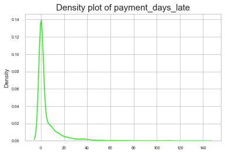

```python
densityPlot(df, "payment_days_late")
```

payment_days_late is another prediction option however for now we will use paid and drop payment_days_late.

```python
x = df.shape
df.drop("payment_days_late", axis = 1, inplace=True)
md(f"Before deletion the width of the dataframe was ***{x[1]}*** after deletion the width of the dataframe is ***{df.shape[1]}*** a difference of ***{df.shape[1] - x[1]}***")
```

Before deletion the width of the dataframe was *108* after deletion the width of the dataframe is *107* a difference of *-1*

### Correlation

#### Removal of ID variables

We used a number of ID variables to identify the dataset. We will now remove most of these references to omit any obvious correlation between these different variables

```python
x = df.shape
df.drop(list(df.columns[df.columns.str.contains("cif")]), axis = 1, inplace=True)
md(f"Before deletion the width of the dataframe was ***{x[1]}*** after deletion the width of the dataframe is ***{df.shape[1]}*** a difference of ***{df.shape[1] - x[1]}***")
```

Before deletion the width of the dataframe was *107* after deletion the width of the dataframe is *104* a difference of *-3*

#### Pre-Cleaning

##### Correlation Matrix

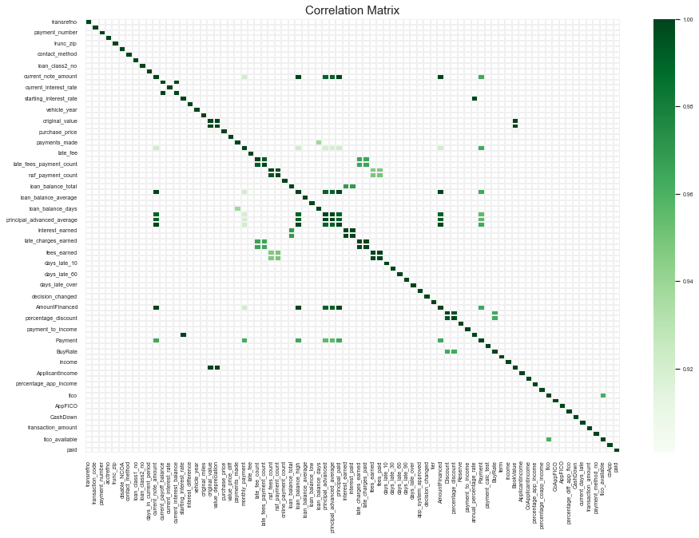

```python
corrDF, correlatedFeatures = corrMatrix(df, returnOption=True)
```

##### Table of Highly correlated features

```python
corrDFHC = pd.melt(corrDF.loc[list(correlatedFeatures)][list(correlatedFeatures)], ignore_index=False).reset_index().rename(columns={"index" : "variableOne", "variable" : "variableTwo", "value" : "Correlation"})
corrDFHC = corrDFHC[(corrDFHC.Correlation > 0.9) & (corrDFHC.Correlation <= 1)].reset_index(drop=True)
corrDFHC = corrDFHC[pd.DataFrame(np.sort(corrDFHC[['variableOne','variableTwo']].values,1)).duplicated()].sort_values(["variableOne"], ascending=[True]).reset_index(drop=True).round(decimals = 2)
printTableHtml(corrDFHC)
```

|  | variableOne | variableTwo | Correlation |
| --- | --- | --- | --- |
| 0 | AmountFinanced | Payment | 0.960000 |
| 1 | AmountFinanced | principal_paid | 1.000000 |
| 2 | AmountFinanced | principal_advanced_average | 0.990000 |
| 3 | BookValue | purchase_price | 0.900000 |
| 4 | BuyRate | percentage_discount | 0.960000 |
| 5 | days_late_10 | late_fees_payment_count | 0.900000 |
| 6 | fees_paid | fees_earned | 1.000000 |
| 7 | interest_earned | interest_paid | 1.000000 |
| 8 | late_charges_paid | late_charges_earned | 1.000000 |
| 9 | late_fees_payment_count | late_charges_earned | 0.960000 |
| 10 | late_fees_payment_count | late_charges_paid | 0.960000 |
| 11 | loan_balance_high | principal_advanced | 0.990000 |
| 12 | loan_balance_high | principal_paid | 1.000000 |
| 13 | loan_balance_high | AmountFinanced | 1.000000 |
| 14 | loan_balance_high | Payment | 0.960000 |
| 15 | loan_balance_high | principal_advanced_average | 0.990000 |
| 16 | monthly_payment | Payment | 0.960000 |
| 17 | monthly_payment | principal_paid | 0.920000 |
| 18 | monthly_payment | loan_balance_high | 0.920000 |
| 19 | monthly_payment | AmountFinanced | 0.920000 |
| 20 | monthly_payment | principal_advanced | 0.920000 |
| 21 | monthly_payment | principal_advanced_average | 0.920000 |
| 22 | nsf_payment_count | fees_earned | 0.950000 |
| 23 | nsf_payment_count | fees_paid | 0.950000 |
| 24 | principal_advanced | AmountFinanced | 0.990000 |
| 25 | principal_advanced | principal_paid | 0.990000 |
| 26 | principal_advanced | Payment | 0.960000 |
| 27 | principal_advanced | principal_advanced_average | 1.000000 |
| 28 | principal_advanced_average | principal_paid | 0.990000 |
| 29 | principal_advanced_average | Payment | 0.960000 |
| 30 | principal_paid | Payment | 0.960000 |
| 31 | value_depreciation | purchase_price | 0.900000 |
| 32 | value_depreciation | BookValue | 1.000000 |

##### Summary Statistics of Highly Correlated Variables

```python
printTableHtml(summaryStatFunc(df[sorted(list(set(list(corrDFHC['variableOne']) + list(corrDFHC['variableTwo']))))]))
```

|  | Type | Coverage | Mean | Mode | Min | Max | Unique Values | Non-Null Values | Null Values | Boolean Weights | Example |
| --- | --- | --- | --- | --- | --- | --- | --- | --- | --- | --- | --- |
| AmountFinanced | float64 | 100.000000 | 19164.960000 | 17326.6 | 7266.120000 | 38896.680000 | 384 | 8457 | 0 | 0.8% | [26245.28, 26245.28, 17326.6, 16947.73, 15363.0] |
| BookValue | float64 | 100.000000 | 16875.840000 | 11575.0 | 6175.000000 | 37823.360000 | 366 | 8457 | 0 | 1.09% | [6175.0, 11775.0, 26290.0, 17614.0, 17425.0] |
| BuyRate | float64 | 100.000000 | 16.020000 | 14.75 | 12.750000 | 99.990000 | 6 | 8457 | 0 | 37.51% | [18.75, 16.75, 14.75, 14.75, 14.75] |
| Payment | float64 | 100.000000 | 436.250000 | 475.0 | 202.540000 | 865.880000 | 374 | 8457 | 0 | 1.25% | [287.23, 532.68, 389.79, 328.41, 361.4] |
| days_late_10 | int64 | 100.000000 | 1.380000 | 0 | -1.000000 | 11.000000 | 11 | 8457 | 0 | 49.66% | [3, 1, 1, 0, 0] |
| fees_earned | float64 | 100.000000 | 7.930000 | 0.0 | 0.000000 | 150.000000 | 14 | 8457 | 0 | 80.75% | [0.0, 0.0, 60.0, 0.0, 0.0] |
| fees_paid | float64 | 100.000000 | 7.930000 | 0.0 | 0.000000 | 150.000000 | 14 | 8457 | 0 | 80.75% | [0.0, 20.0, 0.0, 0.0, 0.0] |
| interest_earned | float64 | 100.000000 | 2556.980000 | 3683.86 | -1336.610000 | 5929.900000 | 384 | 8457 | 0 | 0.8% | [601.28, 1973.32, 729.14, 1063.03, 1973.32] |
| interest_paid | float64 | 100.000000 | 2556.980000 | 3683.86 | -1336.610000 | 5929.900000 | 384 | 8457 | 0 | 0.8% | [2996.14, 5145.55, 3038.46, 2936.99, 2735.52] |
| late_charges_earned | float64 | 100.000000 | 35.760000 | 0.0 | 0.000000 | 278.730000 | 116 | 8457 | 0 | 50.81% | [23.47, 0.0, 15.0, 0.0, 31.26] |
| late_charges_paid | float64 | 100.000000 | 35.760000 | 0.0 | 0.000000 | 278.730000 | 116 | 8457 | 0 | 50.81% | [0.0, 0.0, 0.0, 244.62, 212.29] |
| late_fees_payment_count | int64 | 100.000000 | 1.710000 | 0 | 0.000000 | 12.000000 | 13 | 8457 | 0 | 50.81% | [2, 1, 0, 1, 1] |
| loan_balance_high | float64 | 100.000000 | 19164.960000 | 17326.6 | 7266.120000 | 38896.680000 | 384 | 8457 | 0 | 0.8% | [14541.24, 13692.85, 18383.06, 21080.73, 11000.83] |
| monthly_payment | float64 | 100.000000 | 427.990000 | 475.0 | 102.260000 | 865.880000 | 376 | 8457 | 0 | 0.95% | [271.516, 453.56, 260.29, 472.41, 299.47] |
| nsf_payment_count | int64 | 100.000000 | 0.310000 | 0 | 0.000000 | 4.000000 | 5 | 8457 | 0 | 80.75% | [1, 0, 0, 0, 0] |
| percentage_discount | float64 | 100.000000 | 4.010000 | 2.59 | -1.390000 | 228.810000 | 384 | 8457 | 0 | 0.8% | [2.4778100794444406, 1.7961379433940523, 1.0239038749453804, 0.8137723043246263, 2.3242210753534214] |
| principal_advanced | float64 | 100.000000 | 19305.990000 | 17784.97 | 7618.110000 | 40947.640000 | 384 | 8457 | 0 | 0.8% | [8747.21, 21577.29, 14154.58, 17048.45, 10563.68] |
| principal_advanced_average | float64 | 100.000000 | 19305.990000 | 17784.97 | 7618.110000 | 40947.640000 | 384 | 8457 | 0 | 0.8% | [21819.21, 12890.84, 13066.91, 20695.28, 19901.39] |
| principal_paid | float64 | 100.000000 | 19163.740000 | 17326.6 | 7266.120000 | 38896.680000 | 384 | 8457 | 0 | 0.8% | [21492.95, 19349.13, 16277.86, 15288.3, 22822.83] |
| purchase_price | float64 | 100.000000 | 18097.160000 | 14995.0 | 6750.000000 | 35781.320000 | 330 | 8457 | 0 | 1.48% | [17353.0, 15988.0, 13315.0, 11750.0, 24495.0] |
| value_depreciation | float64 | 100.000000 | 16875.840000 | 11575.0 | 6175.000000 | 37823.360000 | 366 | 8457 | 0 | 1.09% | [16725.0, 11093.0, 15458.0, 14100.0, 13850.0] |

#### Drop Highly Correlated features

```python
upper_tri = corrDF.where(np.triu(np.ones(corrDF.shape),k=1).astype(bool))
dropList = [column for column in upper_tri.columns if any(upper_tri[column] > 0.9)]

x = df.shape
df = df.drop(dropList, axis=1)

counter = 1
markdownString = f"Before deletion the width of the dataframe was ***{x[1]}*** after deletion the width of the dataframe is ***{df.shape[1]}*** a difference of ***{df.shape[1] - x[1]}*** \n\n"
markdownString = markdownString + "The columns dropped are:\n"
markdownString = markdownBulletCreator(dropList, markdownString)
md(markdownString)
```

Before deletion the width of the dataframe was *104* after deletion the width of the dataframe is *79* a difference of *-25*

The columns dropped are:

1. current_interest_balance

2. value_depreciation

3. purchase_price

4. monthly_payment

5. late_fees_payment_count

6. nsf_payment_count

7. loan_balance_high

8. loan_balance_days

9. principal_advanced

10. principal_advanced_average

11. principal_paid

12. interest_earned

13. interest_paid

14. late_charges_earned

15. late_charges_paid

16. fees_earned

17. fees_paid

18. days_late_10

19. AmountFinanced

20. percentage_discount

21. annual_percentage_rate

22. Payment

23. BuyRate

24. BookValue

25. fico_available

#### Post-Cleaning

##### Correlation-Matrix

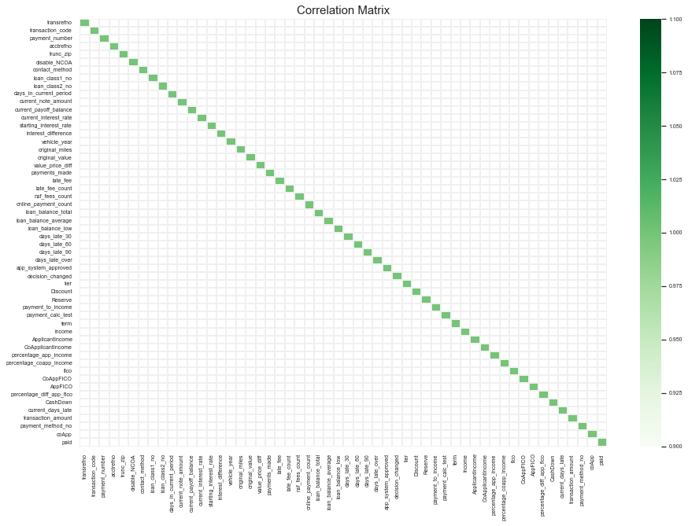

```python
corrDF, correlatedFeatures = corrMatrix(df, returnOption=True)
```

### Removal of information-less variables

There are a number of variables in the dataset that hold no information these need to be removed to reduce clutter and incorrect grouping of transactions.

#### Variables with high unique counts

```python
summaryStatsDF = summaryStatFunc(df)
summaryStatsDF = summaryStatsDF[summaryStatsDF["Unique Values"] >= df.acctrefno.nunique()*0.90].sort_values("Unique Values", ascending=False)
printTableHtml(summaryStatsDF)
```

|  | Type | Coverage | Mean | Mode | Min | Max | Unique Values | Non-Null Values | Null Values | Boolean Weights | Example |
| --- | --- | --- | --- | --- | --- | --- | --- | --- | --- | --- | --- |
| transrefno | int64 | 100.000000 | 6360902.060000 | 8457 modes found | 5441754 | 7322558 | 8457 | 8457 | 0 | 0.01% | [6458911, 6553518, 5755919, 6064804, 6233272] |
| transaction_amount | float64 | 100.000000 | 197.010000 | 30.0 | 0.010000 | 814.830000 | 6237 | 8457 | 0 | 0.48% | [89.35, 15.0, 132.19, 23.75, 102.28] |
| transaction_date | datetime64[ns] | 100.000000 | 2022-02-04 23:39:38.193330944 | 2021-12-21 03:34:40 | 2021-05-06 05:00:25 | 2022-11-01 09:38:31 | 3956 | 8457 | 0 | 0.12% | [Timestamp('2022-10-07 19:01:01'), Timestamp('2022-04-19 07:03:28'), Timestamp('2022-05-01 18:31:12'), Timestamp('2021-12-08 18:00:33'), Timestamp('2021-11-01 08:30:13')] |
| date_due | datetime64[ns] | 100.000000 | 2022-02-09 02:11:16.835757312 | 2021-12-25 00:00:00 | 2021-05-17 00:00:00 | 2023-04-25 00:00:00 | 541 | 8457 | 0 | 0.73% | [Timestamp('2022-01-15 00:00:00'), Timestamp('2022-07-24 00:00:00'), Timestamp('2021-12-25 00:00:00'), Timestamp('2022-07-02 00:00:00'), Timestamp('2021-12-07 00:00:00')] |
| acctrefno | int64 | 100.000000 | 76488.780000 | 76316 | 75210 | 82524 | 384 | 8457 | 0 | 0.8% | [75858, 75938, 76761, 76538, 77424] |
| current_note_amount | float64 | 100.000000 | 19163.770000 | 17326.6 | 7266.120000 | 38896.680000 | 384 | 8457 | 0 | 0.8% | [16969.37, 10019.81, 19240.9, 16911.8, 18255.25] |
| loan_balance_total | float64 | 100.000000 | 5347681.230000 | 7009784.17 | 356157.820000 | 12941814.340000 | 384 | 8457 | 0 | 0.8% | [1530894.49, 5342265.76, 4849891.83, 6047438.24, 4916443.95] |
| loan_balance_average | float64 | 100.000000 | 16872.650000 | 16040.7 | 3650.550000 | 31324.260000 | 384 | 8457 | 0 | 0.8% | [17865.95, 18564.07, 16015.96, 10851.82, 18184.28] |
| original_miles | int64 | 100.000000 | 54728.280000 | 77056 | 0 | 123823 | 381 | 8457 | 0 | 0.8% | [67601, 30997, 10133, 54102, 58821] |
| value_price_diff | float64 | 100.000000 | 1221.320000 | -175.0 | -9150.000000 | 6625.000000 | 371 | 8457 | 0 | 1.02% | [-3890.6, 460.0, -1869.0, 649.0, 1431.0] |
| zip | object | 100.000000 | None | 84129 | 20109 | 99353 | 368 | 8457 | 0 | 1.23% | ['80227', '44306', '98301', '23236', '42141'] |
| original_value | float64 | 100.000000 | 16875.840000 | 11575.0 | 6175.000000 | 37823.360000 | 366 | 8457 | 0 | 1.09% | [27375.0, 15811.0, 19015.0, 21529.0, 16853.0] |

```python
keepList = ["acctrefno", "loan_balance_average", "transaction_amount", "original_miles", "original_value"]
keepListDesc = ["acctrefno: Is the accountID we will need this for future reference [Reference Column]",
            "loan_balance_average: Shows the value of the loan [Linear Information]",
            "transaction_amount: Shows the amount the client has to pay in the month[Linear Information]",
            "original_miles: Shows the miles of the vehicle for which the loan has been taken out[Linear Information]",
            "original_value: Shows the original value of the vehicle [Linear Information]"]

markdownString = "#### Textual explanation regarding variables with high unique counts " \
            "\n In this section we will look at variables with high N counts. " \
            "\n This means that these variables have a lot of different variables in them. " \
            "\n This isn't a problem if a variable holds linear information but the variables who don't need to be removed." \
            "\n "
markdownString = markdownString + "##### Account specific variables \n" \
                        "\n First we have a number of account specific variables. " \
                        "\n These variables do not hold any information except to tie accounts to each other. " \
                        "\n We will remove these variables. " \
                        "\n The account specific variables are: " \
                        "\n"
markdownString = markdownBulletCreator(list(summaryStatsDF.index[(summaryStatsDF['Unique Values'] == df.acctrefno.nunique()) & (~summaryStatsDF.index.isin(keepList))]), markdownString)
markdownString = markdownString + "\n ##### Transaction specific variables \n" \
                        "\n The next set of variables are transaction specific. " \
                        "\n While there are some samples available in these variables they will be so small they will merely introduce bias and noise." \
                        "\n They will also hold no statistical significance. " \
                        "\n The transaction specific variables are:" \
                        "\n"
markdownString = markdownBulletCreator(list(summaryStatsDF.index[(summaryStatsDF['Unique Values'] > df.acctrefno.nunique()) & (~summaryStatsDF.index.isin(keepList))]), markdownString)
markdownString = markdownString + "\n ##### Small sub-sample sizes \n" \
                        "\n The last set of variables have small sub-sample sizes. " \
                        "\n The variables listed below hold no linear numeric information and therefore will be removed. " \
                        "\n A variable like zipcode for example where 84106 is not better then 84105 will be removed. " \
                        "\n The transaction specific variables are:" \
                        "\n"
markdownString = markdownBulletCreator(list(summaryStatsDF.index[(summaryStatsDF['Unique Values'] < df.acctrefno.nunique()) & (~summaryStatsDF.index.isin(keepList))]), markdownString)
markdownString = markdownString + "\n ##### Non Dropped Variables \n" \
                        "\n The last set of variables we will keep for various reasons listed below. " \
                        "\n The variables listed below hold no linear numeric information and therefore will be removed. " \
                        "\n A variable like zipcode for example where 84106 is not better then 84105 will be removed. " \
                        "\n Value_price_diff will also be removed since it can be calculated from loan_balance_average and origional value and will introduce bias when kept. " \
                        "\n The kept variables are:" \
                        "\n"
markdownString = markdownBulletCreator(keepListDesc, markdownString)

md(markdownString)
```

Textual explanation regarding variables with high unique counts

In this section we will look at variables with high N counts. This means that these variables have a lot of different variables in them. This isn't a problem if a variable holds linear information but the variables who don't need to be removed.

Account specific variables

First we have a number of account specific variables. These variables do not hold any information except to tie accounts to each other. We will remove these variables. The account specific variables are:

1. current_note_amount

2. loan_balance_total

   ##### Transaction specific variables

   The next set of variables are transaction specific. While there are some samples available in these variables they will be so small they will merely introduce bias and noise. They will also hold no statistical significance. The transaction specific variables are:

3. transrefno

4. transaction_date

5. date_due

   ##### Small sub-sample sizes

   The last set of variables have small sub-sample sizes. The variables listed below hold no linear numeric information and therefore will be removed. A variable like zipcode for example where 84106 is not better then 84105 will be removed. The transaction specific variables are:

6. value_price_diff

7. zip

   ##### Non Dropped Variables

8. acctrefno: Is the accountID we will need this for future reference [Reference Column]

9. loan_balance_average: Shows the value of the loan [Linear Information]

10. transaction_amount: Shows the amount the client has to pay in the month[Linear Information]

11. original_miles: Shows the miles of the vehicle for which the loan has been taken out[Linear Information]

12. original_value: Shows the original value of the vehicle [Linear Information]

##### Drop variables with high unique Counts

```python
x = df.shape
df.drop(list(df.columns[df.columns.isin(list(summaryStatsDF.index[(~summaryStatsDF.index.isin(keepList))]))]), axis = 1, inplace=True)
md(f"Before deletion the width of the dataframe was ***{x[1]}*** after deletion the width of the dataframe is ***{df.shape[1]}*** a difference of ***{df.shape[1] - x[1]}***")
```

Before deletion the width of the dataframe was *79* after deletion the width of the dataframe is *72* a difference of *-7*

#### Removal of date variables

Date variables hold no information since we want to create statistical profiles for each profile and omit any timeseries analysis. Additionally, transaction_date and date_due are the origin of the target variable and therefore hold the actual information of the target which will provide the model with the answer. All date variables will be removed for the aforementioned reasons.

If needed in the future we can engineer these variables to hold linear information like date differences.

```python
dateStatsDF = summaryStatFunc(subStringSelection(df, "date"))
printTableHtml(dateStatsDF.sort_values("Unique Values", ascending = False))
```

|  | Type | Coverage | Mean | Mode | Min | Max | Unique Values | Non-Null Values | Null Values | Boolean Weights | Example |
| --- | --- | --- | --- | --- | --- | --- | --- | --- | --- | --- | --- |
| curr_maturity_date | datetime64[ns] | 100.000000 | 2027-06-01 07:25:26.073075712 | 2027-05-21 00:00:00 | 2025-05-10 00:00:00 | 2028-09-18 00:00:00 | 276 | 8457 | 0 | 1.93% | [Timestamp('2026-10-25 00:00:00'), Timestamp('2026-07-14 00:00:00'), Timestamp('2027-08-28 00:00:00'), Timestamp('2026-06-03 00:00:00'), Timestamp('2027-11-23 00:00:00')] |
| open_maturity_date | datetime64[ns] | 100.000000 | 2027-05-30 03:28:24.859879424 | 2027-06-11 00:00:00 | 2025-05-10 00:00:00 | 2028-09-18 00:00:00 | 269 | 8457 | 0 | 1.84% | [Timestamp('2027-05-19 00:00:00'), Timestamp('2027-07-31 00:00:00'), Timestamp('2027-06-11 00:00:00'), Timestamp('2027-11-11 00:00:00'), Timestamp('2025-12-25 00:00:00')] |
| next_billing_date | datetime64[ns] | 100.000000 | 2022-07-13 21:24:42.653423360 | 2022-10-30 00:00:00 | 2021-07-20 00:00:00 | 2023-05-10 00:00:00 | 256 | 8457 | 0 | 2.26% | [Timestamp('2022-06-19 00:00:00'), Timestamp('2022-12-21 00:00:00'), Timestamp('2022-10-30 00:00:00'), Timestamp('2022-10-24 00:00:00'), Timestamp('2022-07-18 00:00:00')] |
| open_date | datetime64[ns] | 100.000000 | 2021-08-04 16:43:45.611919360 | 2021-05-22 00:00:00 | 2021-04-05 00:00:00 | 2022-09-03 00:00:00 | 213 | 8457 | 0 | 2.41% | [Timestamp('2021-05-22 00:00:00'), Timestamp('2022-07-06 00:00:00'), Timestamp('2021-11-27 00:00:00'), Timestamp('2021-05-05 00:00:00'), Timestamp('2021-08-27 00:00:00')] |
| curr_date | datetime64[ns] | 100.000000 | 2021-08-04 16:43:45.611919360 | 2021-05-22 00:00:00 | 2021-04-05 00:00:00 | 2022-09-03 00:00:00 | 213 | 8457 | 0 | 2.41% | [Timestamp('2021-10-29 00:00:00'), Timestamp('2021-12-18 00:00:00'), Timestamp('2022-02-12 00:00:00'), Timestamp('2021-07-22 00:00:00'), Timestamp('2022-01-20 00:00:00')] |
| last_rate_change_date | datetime64[ns] | 100.000000 | 2021-08-04 16:43:45.611919360 | 2021-05-22 00:00:00 | 2021-04-05 00:00:00 | 2022-09-03 00:00:00 | 213 | 8457 | 0 | 2.41% | [Timestamp('2021-06-02 00:00:00'), Timestamp('2021-05-25 00:00:00'), Timestamp('2021-05-10 00:00:00'), Timestamp('2021-04-21 00:00:00'), Timestamp('2021-10-12 00:00:00')] |
| last_activity_date | datetime64[ns] | 100.000000 | 2022-06-14 00:54:49.677190656 | 2022-09-30 00:00:00 | 2021-07-14 00:00:00 | 2022-11-01 00:00:00 | 203 | 8457 | 0 | 2.87% | [Timestamp('2022-07-05 00:00:00'), Timestamp('2022-08-09 00:00:00'), Timestamp('2022-10-21 00:00:00'), Timestamp('2022-10-14 00:00:00'), Timestamp('2022-04-28 00:00:00')] |

##### Drop date variables

```python
x = df.shape
df.drop(list(df.columns[df.columns.isin(subStringSelection(df, "date", returnOption="columns"))]), axis = 1, inplace=True)
df.drop(list(df.columns[df.columns.isin(subStringSelection(df, "next_accrual_cutoff", returnOption="columns"))]), axis = 1, inplace=True)

md(f"Before deletion the width of the dataframe was ***{x[1]}*** after deletion the width of the dataframe is ***{df.shape[1]}*** a difference of ***{df.shape[1] - x[1]}***")
```

Before deletion the width of the dataframe was *72* after deletion the width of the dataframe is *64* a difference of *-8*

## Machine Learning preparation

### Categorical Variables

To save computing power we will label encode categorical variables with high unique counts, so we won't make an extremely large number of columns when dummy encoding.

```python
catStatsDF = summaryStatFunc(df.select_dtypes(include=['object']))
catStatsDF = catStatsDF.sort_values("Unique Values", ascending = False).loc[catStatsDF["Unique Values"] > 25]
printTableHtml(catStatsDF)
```

|  | Type | Coverage | Mean | Mode | Min | Max | Unique Values | Non-Null Values | Null Values | Boolean Weights | Example |
| --- | --- | --- | --- | --- | --- | --- | --- | --- | --- | --- | --- |
| city | object | 100.000000 | None | AURORA | ACWORTH | ZANESVILLE | 276 | 8457 | 0 | 2.66% | ['DUMFRIES', 'ONALASKA', 'DEFIANCE', 'DENVER', 'AUBURN'] |
| vehicle_model | object | 100.000000 | None | SENTRA | 200 | YUKON | 129 | 8457 | 0 | 4.02% | ['MALIBU', 'JOURNEY', 'PASSAT', 'SOUL', 'COROLLA'] |
| vehicle_make | object | 100.000000 | None | KIA | ACURA | VOLKSWAGEN | 30 | 8457 | 0 | 13.15% | ['JEEP', 'TOYOTA', 'HYUNDAI', 'MITSUBISHI', 'FORD'] |
| state | object | 100.000000 | None | CO | AL | WI | 27 | 8457 | 0 | 13.08% | ['VA', 'UT', 'AZ', 'IL', 'WA'] |

```python
labelEncoder = LabelEncoder()

# Save unlabeled df
df.to_csv("dfCleanNoLabel.csv")

for indexName in list(catStatsDF.index):
    df[indexName] = labelEncoder.fit_transform(df[indexName])
    print(f"Encoded {indexName} in df.")
```

```
Encoded city in df.
Encoded vehicle_model in df.
Encoded vehicle_make in df.
Encoded state in df.
```

### Dummy Encoding

Here we one-hot encode or dummy encode the dataset. For every categorical level we will get a new boolean variable with. This removes any linear information in categorical variables.

```python
# Save shape of the dataframe
x = df.shape

# Remove target variable
dfTarget = df["paid"]
df.drop("paid", axis = 1, inplace = True)

# Dummy encode
dummyDf = pd.get_dummies(df)

# Add target back
dummyDf["target"] = dfTarget

# Print results
md(f"Before dummy encoding the width of the dataframe was ***{x[1]}*** after dummy encoding the width of the dataframe is ***{dummyDf.shape[1]}*** a difference of ***{dummyDf.shape[1] - x[1]}***")
```

Before dummy encoding the width of the dataframe was *64* after dummy encoding the width of the dataframe is *91* a difference of *27*

### DataSet Exports

```python
dummyDf.to_csv("dummiesClean.csv")
dfTarget.to_csv("targetDf.csv")
df.to_csv("cleanedDf.csv")
```

### Dataset Scaling

We scale the dataset so statistical assumptions of some models hold true regarding the range of the data. This also makes the data comparable for a model.

```python
column_names = list(dummyDf.keys())
dataframe_scaler = MinMaxScaler()
dfScaled = dataframe_scaler.fit_transform(dummyDf)
dfScaled = pd.DataFrame(data = dfScaled, columns= column_names)

joblib.dump(dataframe_scaler, 'scaler.gz')

print("The dataframe completed scaling.")
```

```
The dataframe completed scaling.
```

### Creation of Test and Training Sets

```python
dfTarget  = dummyDf["target"]
dummyDf.drop("target", axis = 1, inplace = True)
dfScaled.drop("target", axis = 1, inplace = True)

xTrain, xTest, yTrain, yTest = train_test_split(dfScaled, dfTarget, test_size=0.25, random_state=33)


md(f"The test and train sets have been created. \n "
   f"The Train set has a length of ***{xTrain.shape[0]}*** and a width of ***{xTrain.shape[1]}***. \n"
   f"The Test set has a length of ***{xTest.shape[0]}*** and a width of ***{xTest.shape[1]}***. ")
```

The test and train sets have been created. The Train set has a length of *6342* and a width of *90*. The Test set has a length of *2115* and a width of *90*.

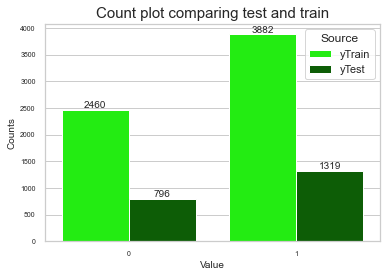

```python
barPlotCompare(yTest, yTrain)
```

## Machine Learning

### Naive Bayes

```python
gnb = GaussianNB()
yPredOos = gnb.fit(xTrain, yTrain).predict(xTest)
yPredIs =gnb.fit(xTrain, yTrain).predict(xTrain)
md(f"The accuracy of the model is ***{round(accuracy_score(yTest, yPredOos) * 100, 2)}%*** for out-of-sample and ***{round(accuracy_score(yTrain, yPredIs) * 100, 2)}%*** for in-sample")
```

The accuracy of the model is *65.25%* for out-of-sample and *64.63%* for in-sample

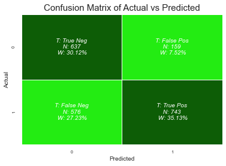

```python
confusionMatrix(yPredOos, yTest, returnOption="graph")
```

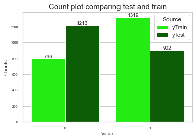

```python
barPlotCompare(pd.DataFrame(yPredOos).rename(columns = {0 : "Count"}), pd.DataFrame(yTest).rename(columns = {0 : "Count"}))
```

### K Nearest Neighbours

```python
knn = KNeighborsClassifier()
knn.fit(xTrain, yTrain)

yPredIs = knn.predict(xTrain)
yPredOos = knn.predict(xTest)

md(f"The accuracy of the model is ***{round(accuracy_score(yTest, yPredOos) * 100, 2)}%*** for out-of-sample and ***{round(accuracy_score(yTrain, yPredIs) * 100, 2)}%*** for in-sample")
```

The accuracy of the model is *76.12%* for out-of-sample and *83.19%* for in-sample

```python
max_neighbours = 10
step_size = 1

bestOos = 0
bestNeighbours = 0

scoreOos = []
scoreIs = []


for x in range(1, max_neighbours+1, step_size):
    knn = KNeighborsClassifier(n_neighbors=x)
    knn.fit(xTrain, yTrain)

    # In Sample
    yPredOos = knn.predict(xTest)
    accOos = accuracy_score(yTest, yPredOos)

    # Out of sample
    yPredIs = knn.predict(xTrain)
    accIs = accuracy_score(yTrain, yPredIs)

    # append to dict
    scoreOos.append(accOos)
    scoreIs.append(accIs)


    # Update Output
    if accOos > bestOos:
        if accIs > .95:
            pass
        else:
            bestOos = accOos
            bestNeighbours = x

knn = KNeighborsClassifier(n_neighbors=bestNeighbours)
knn.fit(xTrain, yTrain)

yPredIs = knn.predict(xTrain)
yPredOos = knn.predict(xTest)

md(f"The accuracy of the model with {bestNeighbours} Neighbours is ***{round(accuracy_score(yTest, yPredOos) * 100, 2)}%*** for out-of-sample and ***{round(accuracy_score(yTrain, yPredIs) * 100, 2)}%*** for in-sample")
```

The accuracy of the model with 3 Neighbours is *77.59%* for out-of-sample and *87.8%* for in-sample

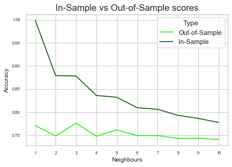

```python
meltDF = pd.DataFrame({"Out-of-Sample" : scoreOos, "In-Sample" : scoreIs}).reset_index()
meltDF = pd.melt(meltDF, ['index']).rename(columns={"variable" : "Type"})
meltDF["index"] += 1
linePlot(meltDF, colName="value", hue = "Type", xLabel= "Neighbours", yLabel="Accuracy", graphTitle="In-Sample vs Out-of-Sample scores")
```

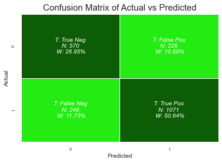

```python
confusionMatrix(yPredOos, yTest, returnOption="graph")
```

### XGBoost

```python
xgb_cl = xgb.XGBClassifier()

# Out of Sample
xgb_cl.fit(xTrain, yTrain)
yPredOos = xgb_cl.predict(xTest)

# In-Sample
yPredIs = xgb_cl.predict(xTrain)

md(f"The accuracy of the intial model is ***{round(accuracy_score(yTest, yPredOos) * 100, 2)}%*** for out-of-sample and ***{round(accuracy_score(yTrain, yPredIs) * 100, 2)}%*** for in-sample")
```

[output not shown]

The accuracy of the intial model is *86.48%* for out-of-sample and *98.16%* for in-sample

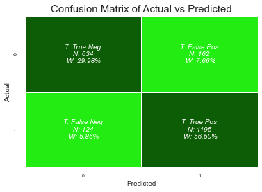

```python
confusionMatrix(yPredOos, yTest, returnOption="graph")
```

#### GridSearching

```python
# paramGrid = {"n_estimators" : list(range(800,1400,200)),
#               "max_depth" : list(range(3,8,1)),
#               "alpha" : [0.1,0.5],
#               "learning_rate" : [0.1],
#               "colsample_bytree" : [0.8,0.5],
#               "lambda" : [1],
#               "subsample": [1]}

paramGrid = {"n_estimators" : list(range(800,1200,200)),
              "max_depth" : list(range(4,7,1)),
              "alpha" : [0.5],
              "learning_rate" : [0.1],
              "colsample_bytree" : [0.8],
              "lambda" : [1],
              "subsample": [1]}

paramGrid = pd.DataFrame(ParameterGrid(paramGrid))

kf = KFold(n_splits=3, shuffle=True, random_state=42)

counter = 0
xgboost_timer_start = timeit.default_timer()
optimalAucFold = 0
optimalAccFold = 0
verboseDict = {}
optimalParamDict = {}
for epoch in range(len(paramGrid)):

    xgboost_timer_lap= timeit.default_timer()
    # Run Model
    xgRegressor = xgb.XGBClassifier(objective ='binary:logistic',
                                   n_estimators = paramGrid["n_estimators"][epoch],
                                   max_depth = paramGrid["max_depth"][epoch],
                                   reg_alpha = paramGrid["alpha"][epoch],
                                   learning_rate = paramGrid["learning_rate"][epoch],
                                   colsample_bytree = paramGrid["colsample_bytree"][epoch],
                                   reg_lambda = paramGrid["lambda"][epoch],
                                   subsample = paramGrid["subsample"][epoch],
                                   verbosity = 0,
                                   use_label_encoder=False)


    accFold = []
    aucFold = []
    try:
        for Train_index, Test_index in kf.split(xTrain, yTrain):
            xTrainFold, xTestFold = xTrain.iloc[Train_index], xTrain.iloc[Test_index]
            yTrainFold, yTestFold = yTrain.iloc[Train_index], yTrain.iloc[Test_index]
            xgRegressor.fit(xTrainFold, yTrainFold)

            yTestFoldPred = xgRegressor.predict(xTestFold)
            accFold.append(accuracy_score(yTestFold, yTestFoldPred))
            aucFold.append(roc_auc_score(yTestFold, yTestFoldPred))

        meanFoldAcc = np.mean(accFold)
        meanFoldAuc = np.mean(aucFold)

    except Exception as e:
        raise Exception(e)

    if meanFoldAuc > optimalAucFold:
        optimalAucFold = meanFoldAuc
        optimalAccFold = meanFoldAcc
        optimalParamDict = {"objective" : 'binary:logistic',
                            "n_estimators" : paramGrid["n_estimators"][epoch],
                             "max_depth" : paramGrid["max_depth"][epoch],
                             "reg_alpha" : paramGrid["alpha"][epoch],
                             "learning_rate" : paramGrid["learning_rate"][epoch],
                             "colsample_bytree" : paramGrid["colsample_bytree"][epoch],
                             "reg_lambda" : paramGrid["lambda"][epoch],
                             "subsample": paramGrid["subsample"][epoch],
                              "verbose" : 0}

    counter += 1
    xgboost_timer_stop = timeit.default_timer()

    if counter % 100 == 0 or counter == 1 or counter == len(paramGrid):
        print(f"Epoch {counter}/{len(paramGrid)} | time elapsed = {str(datetime.timedelta(seconds = round(xgboost_timer_stop - xgboost_timer_start,0)))}, "
              f"estimated time remaining {str(datetime.timedelta(seconds = round((xgboost_timer_stop - xgboost_timer_lap) * (len(paramGrid) - counter),0)))}")
    else:
        pass

    epochParamGrid = {"Mean Fold Accuracy": meanFoldAcc,
                      "Mean Fold Auc": meanFoldAuc,
                      "n_estimators": paramGrid["n_estimators"][epoch],
                      "max_depth": paramGrid["max_depth"][epoch],
                      "reg_alpha": paramGrid["alpha"][epoch],
                      "learning_rate": paramGrid["learning_rate"][epoch],
                      "colsample_bytree": paramGrid["colsample_bytree"][epoch],
                      "reg_lambda": paramGrid["lambda"][epoch],
                      "subsample": paramGrid["subsample"][epoch]}

    verboseDict[epoch+1] = epochParamGrid
```

```python
# Rerun the model with optimal parameters
xgRegressor = xgb.XGBClassifier(objective ='binary:logistic',
                           n_estimators = optimalParamDict["n_estimators"],
                           max_depth = optimalParamDict["max_depth"],
                           reg_alpha = optimalParamDict["reg_alpha"],
                           learning_rate = optimalParamDict["learning_rate"],
                           colsample_bytree = optimalParamDict["colsample_bytree"],
                           reg_lambda = optimalParamDict["reg_lambda"],
                           subsample = optimalParamDict["subsample"],
                           verbosity = 0,
                           use_label_encoder=False)

xgRegressor.fit(xTrain, yTrain)
yPredOos = xgRegressor.predict(xTest)
yPredIs = xgRegressor.predict(xTrain)
```

```python
markdownString = f"The optimal Auc is {round(optimalAucFold, 2)} and the optimal accuracy is {round(optimalAccFold, 2)} \n  with the hyperparameters: \n"
markdownString = markdownBulletCreatorDict(optimalParamDict, markdownString)

md(markdownString)
```

The optimal Auc is 0.84 and the optimal accuracy is 0.85 with the hyperparameters:

1. objective = binary:logistic

2. n_estimators = 800

3. max_depth = 5

4. reg_alpha = 0.5

5. learning_rate = 0.1

6. colsample_bytree = 0.8

7. reg_lambda = 1

8. subsample = 1

9. verbose = 0

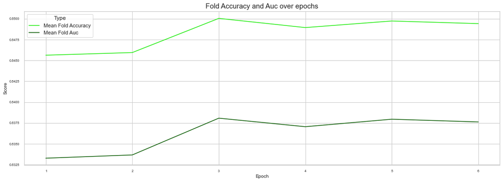

```python
lineDF = pd.melt(pd.DataFrame(verboseDict).transpose().reset_index(), id_vars = ['index'], value_vars = ["Mean Fold Accuracy", "Mean Fold Auc"]).rename(columns={"variable" : "Type"})
linePlot(lineDF, colName="value", hue = "Type", xLabel= "Epoch", yLabel="Score", graphTitle="Fold Accuracy and Auc over epochs", figSize = (18,6), setAxis = False)
```

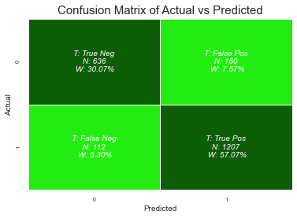

```python
confusionMatrix(yPredOos, yTest, returnOption="graph")
```

```python
printTableHtml(pd.DataFrame(verboseDict).transpose())
```

|  | Mean Fold Accuracy | Mean Fold Auc | n_estimators | max_depth | reg_alpha | learning_rate | colsample_bytree | reg_lambda | subsample |
| --- | --- | --- | --- | --- | --- | --- | --- | --- | --- |
| 1 | 0.845632 | 0.833278 | 800.000000 | 4.000000 | 0.500000 | 0.100000 | 0.800000 | 1.000000 | 1.000000 |
| 2 | 0.845948 | 0.833668 | 1000.000000 | 4.000000 | 0.500000 | 0.100000 | 0.800000 | 1.000000 | 1.000000 |
| 3 | 0.850047 | 0.838079 | 800.000000 | 5.000000 | 0.500000 | 0.100000 | 0.800000 | 1.000000 | 1.000000 |
| 4 | 0.848944 | 0.837053 | 1000.000000 | 5.000000 | 0.500000 | 0.100000 | 0.800000 | 1.000000 | 1.000000 |
| 5 | 0.849732 | 0.837954 | 800.000000 | 6.000000 | 0.500000 | 0.100000 | 0.800000 | 1.000000 | 1.000000 |
| 6 | 0.849417 | 0.837625 | 1000.000000 | 6.000000 | 0.500000 | 0.100000 | 0.800000 | 1.000000 | 1.000000 |

##### Probabilities

###### Out-of-Sample

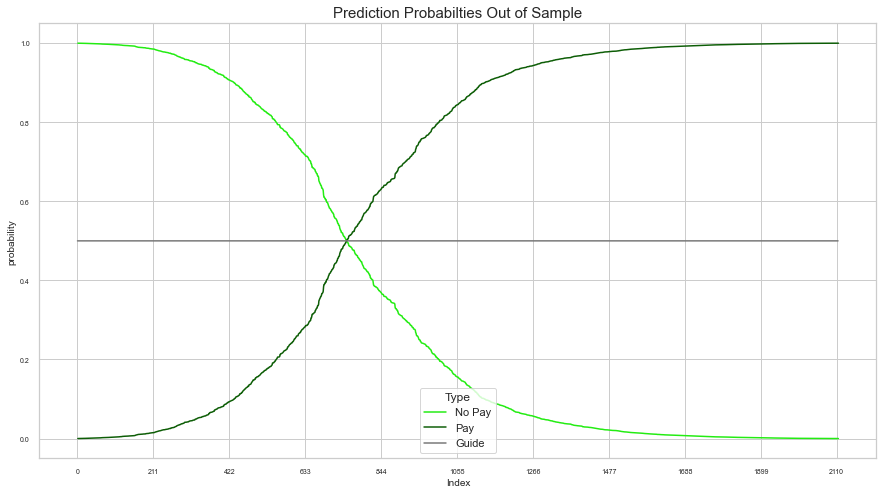

```python
yPredOosProb = xgRegressor.predict_proba(xTest)
yPredOosProb= pd.DataFrame(yPredOosProb).rename(columns={0 : "No Pay", 1 : "Pay"})
yPredOosProb = yPredOosProb.sort_values("No Pay", ascending=False)

indexList = list(range(len(yPredOosProb))) + list(range(len(yPredOosProb)))
yPredOosProb = pd.melt(yPredOosProb.reset_index(), ['index']).rename(columns={"variable" : "Type", "value" : "probability"})
yPredOosProb['index'] = indexList
yPredOosProb["index"] += 1
linePlot(yPredOosProb, colName="probability", hue = "Type", xLabel= "Index", yLabel="probability", graphTitle="Prediction Probabilties Out of Sample", figSize=[15,8], splitLine=True)
```

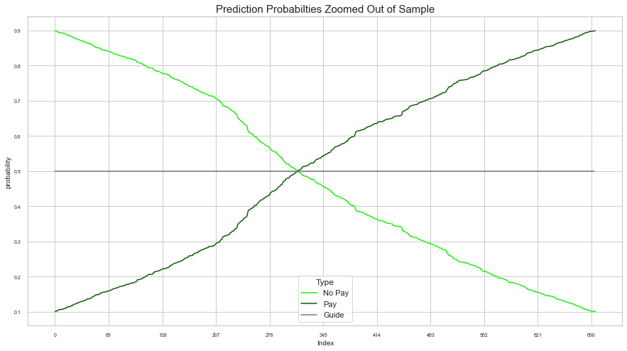

```python
tempDf = yPredOosProb[(yPredOosProb["probability"] > 0.1) & (yPredOosProb["probability"] < 0.9)].drop("index", axis = 1).reset_index(drop=True)
lengthtempDf = np.unique(tempDf.Type, return_counts=True)[1][0]
indexList = list(range(lengthtempDf)) + list(range(lengthtempDf))
tempDf['index'] = indexList
linePlot(tempDf, colName="probability", hue = "Type", xLabel= "Index", yLabel="probability", graphTitle="Prediction Probabilties Zoomed Out of Sample", figSize=[15,8], splitLine=True)
```

###### In-Sample

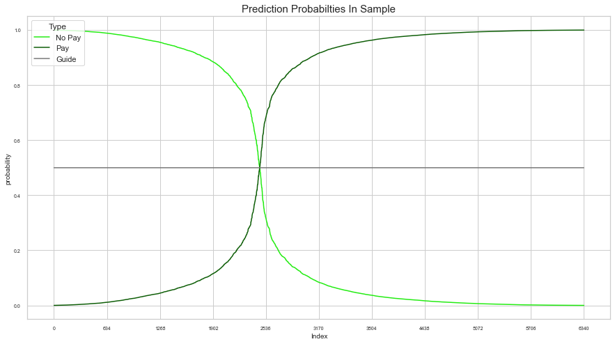

```python
yPredIsProb = xgRegressor.predict_proba(xTrain)
yPredIsProb = pd.DataFrame(yPredIsProb ).rename(columns={0 : "No Pay", 1 : "Pay"})
yPredIsProb  = yPredIsProb .sort_values("No Pay", ascending=False)

indexList = list(range(len(yPredIsProb))) + list(range(len(yPredIsProb)))
yPredIsProb = pd.melt(yPredIsProb.reset_index(), ['index']).rename(columns={"variable" : "Type", "value" : "probability"})
yPredIsProb['index'] = indexList
yPredIsProb["index"] += 1
linePlot(yPredIsProb, colName="probability", hue = "Type", xLabel= "Index", yLabel="probability", graphTitle="Prediction Probabilties In Sample", figSize=[15,8], splitLine=True)
```

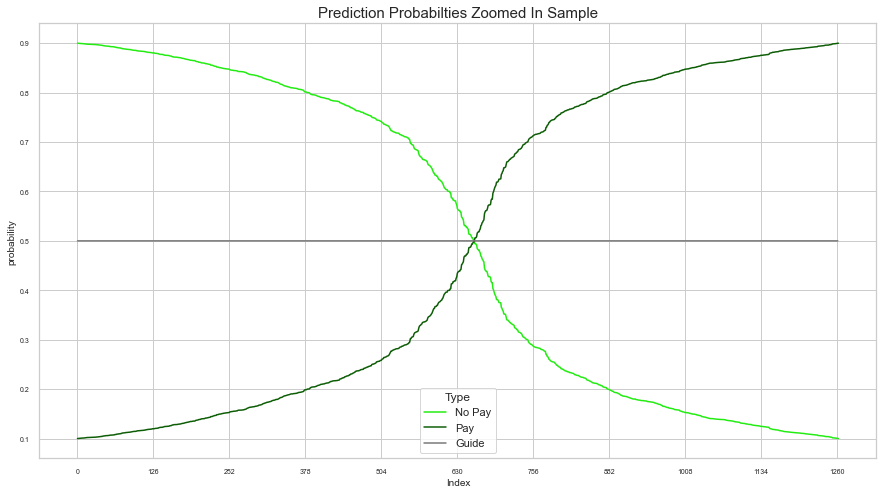

```python
tempDf = yPredIsProb[(yPredIsProb["probability"] > 0.1) & (yPredIsProb["probability"] < 0.9)].drop("index", axis = 1).reset_index(drop=True)
lengthtempDf = np.unique(tempDf.Type, return_counts=True)[1][0]
indexList = list(range(lengthtempDf)) + list(range(lengthtempDf))
tempDf['index'] = indexList
linePlot(tempDf, colName="probability", hue = "Type", xLabel= "Index", yLabel="probability", graphTitle="Prediction Probabilties Zoomed In Sample", figSize=[15,8], splitLine=True)
```

The difference in sureness between in-sample and out of sample is quite large. You can see a more gradual descent in the out-of-sample predictions towards the middle point of 0.5 this shows more uncertainty.

##### Variable Importance

```python
varImpDf = pd.DataFrame(dummyDf.columns.values.tolist())
varImpDf['importance'] = xgRegressor.feature_importances_
varImpDf = varImpDf.sort_values('importance', ascending=False)
varImpDf
```

|  | 0 | importance |
| --- | --- | --- |
| 22 | late_fee_count | 0.105766 |
| 28 | days_late_60 | 0.046875 |
| 77 | Contract_BKType_BK 13 | 0.040731 |
| 54 | transaction_description_P+I Principal Payment | 0.038008 |
| 21 | late_fee | 0.034971 |
| 57 | entity_COUPLE | 0.030825 |
| 32 | decision_changed | 0.025926 |
| 10 | days_in_current_period | 0.024177 |
| 45 | CoAppFICO | 0.022855 |
| 67 | previous_collection_status_TERMINATED | 0.020192 |
| 27 | days_late_30 | 0.019866 |
| 0 | transaction_code | 0.018577 |
| 49 | current_days_late | 0.017825 |
| 61 | HousingType_Rent Ch 13? | 0.017408 |
| 47 | percentage_diff_app_fico | 0.016319 |
| 85 | Contract_CreditTier_4 | 0.016190 |
| 25 | loan_balance_average | 0.015902 |
| 84 | Contract_CreditTier_3 | 0.013941 |
| 31 | app_system_approved | 0.013910 |
| 51 | payment_method_no | 0.013495 |
| 73 | previous_late_bucket_ON TIME | 0.013385 |
| 83 | Contract_CreditTier_2 | 0.012063 |
| 19 | original_value | 0.011478 |
| 14 | interest_difference | 0.011132 |
| 20 | payments_made | 0.011114 |
| 88 | Contract_CreditTier_RV 4 | 0.011084 |
| 12 | current_interest_rate | 0.010448 |
| 24 | online_payment_count | 0.010312 |
| 62 | HousingType_Rent Ch 7? | 0.010284 |
| 3 | state | 0.010133 |

[output cut: 60 more lines]

#### False Positives

False Positives are the most detrimental to the implentation of the model. We want to call people that are not going to pay and a false positive would prevent that, so we will further investigate the profiles of false positives.

```python
falsePositiveOos = xTest
falsePositiveOos['predicted'] = yPredOos
falsePositiveOos['actual'] = yTest
falsePositiveOos = falsePositiveOos[(falsePositiveOos['predicted'] != falsePositiveOos['actual']) & (falsePositiveOos['predicted'] == 1)]

actualPositiveOos = xTest
actualPositiveOos['predicted'] = yPredOos
actualPositiveOos['actual'] = yTest
actualPositiveOos = actualPositiveOos[(actualPositiveOos['predicted'] == actualPositiveOos['actual']) & (actualPositiveOos['predicted'] == 1)]
```

```python
summaryStatsFalsePos = summaryStatFunc(falsePositiveOos)
printTableHtml(summaryStatsFalsePos)
```

|  | Type | Coverage | Mean | Mode | Min | Max | Unique Values | Non-Null Values | Null Values | Boolean Weights | Example |
| --- | --- | --- | --- | --- | --- | --- | --- | --- | --- | --- | --- |
| transaction_code | float64 | 100.000000 | 0.310000 | 0.0 | 0.000000 | 1.000000 | 4 | 160 | 0 | 52.5% | [0.0, 0.0, 0.0, 0.6666666666666572, 0.0] |
| payment_number | float64 | 100.000000 | 0.210000 | 0.04 | 0.000000 | 0.650000 | 16 | 160 | 0 | 11.88% | [0.26086956521739135, 0.0, 0.26086956521739135, 0.08695652173913043, 0.26086956521739135] |
| acctrefno | float64 | 100.000000 | 0.180000 | 0.07 ,0.13 ,0.17 ,0.38 | 0.000000 | 1.000000 | 112 | 160 | 0 | 2.5% | [0.13371616078753057, 0.206043204812687, 0.206043204812687, 0.2269619907027618, 0.14615805304894636] |
| state | float64 | 100.000000 | 0.550000 | 0.12 ,0.92 | 0.000000 | 1.000000 | 21 | 160 | 0 | 11.88% | [0.19230769230769232, 0.9615384615384616, 0.9230769230769231, 0.11538461538461539, 0.11538461538461539] |
| city | float64 | 100.000000 | 0.510000 | 0.25 | 0.000000 | 1.000000 | 93 | 160 | 0 | 6.25% | [0.44363636363636366, 0.45454545454545453, 0.9272727272727272, 0.4109090909090909, 0.29454545454545455] |
| trunc_zip | float64 | 100.000000 | 0.530000 | 5 modes found | 0.000000 | 0.990000 | 107 | 160 | 0 | 2.5% | [0.5093382464287517, 0.04700671344202717, 0.7587577608399374, 0.7587577608399374, 0.1266215738731008] |
| disable_NCOA | float64 | 100.000000 | 0.390000 | 0.0 | 0.000000 | 1.000000 | 2 | 160 | 0 | 61.25% | [0.0, 0.0, 0.0, 0.0, 0.0] |
| contact_method | float64 | 100.000000 | 0.610000 | 1.0 | 0.000000 | 1.000000 | 2 | 160 | 0 | 61.25% | [1.0, 0.0, 0.0, 1.0, 0.0] |
| loan_class1_no | float64 | 100.000000 | 0.590000 | 0.85 | 0.000000 | 1.000000 | 5 | 160 | 0 | 45.62% | [0.0, 0.8461538461538463, 0.8461538461538463, 0.9615384615384616, 0.8461538461538463] |
| loan_class2_no | float64 | 100.000000 | 0.300000 | 0.0 | 0.000000 | 1.000000 | 8 | 160 | 0 | 25.0% | [0.5, 0.30000000000000004, 0.0, 0.5, 0.9000000000000004] |
| days_in_current_period | float64 | 100.000000 | 0.050000 | 0.02 | 0.000000 | 1.000000 | 8 | 160 | 0 | 51.25% | [0.023999999999999994, 0.0, 0.023999999999999994, 0.023999999999999994, 0.023999999999999994] |
| current_payoff_balance | float64 | 100.000000 | 0.010000 | 0.0 | 0.000000 | 1.000000 | 2 | 160 | 0 | 99.38% | [0.0, 0.0, 0.0, 0.0, 0.0] |
| current_interest_rate | float64 | 100.000000 | 0.770000 | 0.73 | 0.460000 | 1.000000 | 10 | 160 | 0 | 40.62% | [0.5932203389830508, 0.728813559322034, 0.8644067796610169, 0.728813559322034, 0.728813559322034] |
| starting_interest_rate | float64 | 100.000000 | 0.570000 | 0.5 | 0.000000 | 1.000000 | 10 | 160 | 0 | 40.62% | [0.625, 0.75, 0.5, 1.0, 0.75] |
| interest_difference | float64 | 100.000000 | 0.000000 | 0.0 | 0.000000 | 0.000000 | 1 | 160 | 0 | 100.0% | [0.0, 0.0, 0.0, 0.0, 0.0] |
| vehicle_year | float64 | 100.000000 | 0.520000 | 0.55 | 0.090000 | 1.000000 | 11 | 160 | 0 | 18.12% | [0.45454545454546746, 0.45454545454546746, 0.2727272727272805, 0.7272727272727479, 0.7272727272727479] |
| vehicle_make | float64 | 100.000000 | 0.570000 | 0.62 | 0.000000 | 1.000000 | 21 | 160 | 0 | 14.37% | [0.8275862068965517, 0.8275862068965517, 0.6206896551724138, 0.5862068965517241, 1.0] |
| vehicle_model | float64 | 100.000000 | 0.490000 | 0.09 | 0.000000 | 0.990000 | 62 | 160 | 0 | 6.88% | [0.8671875, 0.0859375, 0.875, 0.5546875, 0.6328125] |
| original_miles | float64 | 100.000000 | 0.450000 | 0.0 ,0.32 ,0.49 ,0.52 | 0.000000 | 1.000000 | 112 | 160 | 0 | 2.5% | [0.22870549090233638, 0.17201166180758015, 0.22902045661952947, 0.3893622348029041, 0.6816100401379388] |
| original_value | float64 | 100.000000 | 0.330000 | 0.3 ,0.32 ,0.5 ,0.63 | 0.000000 | 0.750000 | 109 | 160 | 0 | 2.5% | [0.17994613306977045, 0.3365103278653302, 0.32747352469448654, 0.3292113714581104, 0.2069617509406491] |
| payments_made | float64 | 100.000000 | 0.420000 | 0.48 | 0.000000 | 0.780000 | 18 | 160 | 0 | 13.12% | [0.26086956521739135, 0.6956521739130435, 0.30434782608695654, 0.4782608695652174, 0.21739130434782608] |
| late_fee | float64 | 100.000000 | 0.300000 | 0.0 | 0.000000 | 0.780000 | 44 | 160 | 0 | 41.88% | [0.5331429251457812, 0.3570153516601214, 0.720694989884565, 0.0, 0.29679876234678093] |
| late_fee_count | float64 | 100.000000 | 0.140000 | 0.0 | 0.000000 | 0.830000 | 11 | 160 | 0 | 48.75% | [0.08333333333333333, 0.0, 0.5, 0.16666666666666666, 0.0] |
| nsf_fees_count | float64 | 100.000000 | 0.070000 | 0.0 | 0.000000 | 1.000000 | 5 | 160 | 0 | 85.62% | [0.0, 0.0, 0.0, 0.0, 0.0] |
| online_payment_count | float64 | 100.000000 | 0.270000 | 0.0 | 0.000000 | 1.000000 | 32 | 160 | 0 | 21.25% | [0.16279069767441862, 0.37209302325581395, 0.2558139534883721, 0.6046511627906976, 0.0] |
| loan_balance_average | float64 | 100.000000 | 0.470000 | 0.2 ,0.45 ,0.53 ,0.79 | 0.000000 | 1.000000 | 112 | 160 | 0 | 2.5% | [0.2796495301858696, 0.5688583135401796, 0.3960184593970234, 0.3850596829987739, 0.2769917730582564] |
| loan_balance_low | float64 | 100.000000 | 0.820000 | 1.0 | 0.190000 | 1.000000 | 64 | 160 | 0 | 41.88% | [1.0, 0.7667531302414479, 0.911899793267543, 0.5441159262004135, 1.0] |
| days_late_30 | float64 | 100.000000 | 0.190000 | 0.14 | 0.000000 | 0.570000 | 5 | 160 | 0 | 76.88% | [0.14285714285714285, 0.2857142857142857, 0.14285714285714285, 0.14285714285714285, 0.2857142857142857] |
| days_late_60 | float64 | 100.000000 | 0.010000 | 0.0 | 0.000000 | 0.250000 | 2 | 160 | 0 | 94.38% | [0.0, 0.0, 0.0, 0.0, 0.0] |
| days_late_90 | float64 | 100.000000 | 0.040000 | 0.0 | 0.000000 | 1.000000 | 2 | 160 | 0 | 95.62% | [0.0, 0.0, 0.0, 0.0, 0.0] |

[output cut: 62 more lines]

```python
compareDF1 = summaryStatsFalsePos.drop(["Unique Values", "Non-Null Values", "Example"], axis = 1)
compareDF2 = summaryStatFunc(actualPositiveOos).drop(["Unique Values", "Non-Null Values", "Example"], axis = 1)
comparedDF = compareDF1.compare(compareDF2).reset_index()
comparedDF.columns.set_levels(['False','Actual','Variables'],level=1, inplace = True)
treshold = 25

def highlight_cells(dataframe):
    color = 'background-color: #23ec12'
    df1 = pd.DataFrame('', index=dataframe.index, columns=dataframe.columns)
    for x in range(len(dataframe)):
        for y in [1,3,5,7,9]:
            if "%" in str(dataframe.iloc[x,y]):
                temp1 = str(dataframe.iloc[x,y+1][:-1])
                temp2 = str(dataframe.iloc[x,y][:-1])
                if abs((float(temp1) - float(temp2)) / float(temp1))*100 > treshold:
                    df1.iloc[x,y] = color
            elif isinstance(dataframe.iloc[x,y], str):
                pass
            elif (dataframe.iloc[x, y] == 0) | (dataframe.iloc[x, y + 1] == 0):
                pass
            else:
                if abs((dataframe.iloc[x,y+1] - dataframe.iloc[x,y]) / dataframe.iloc[x,y+1])*100 > treshold:
                    df1.iloc[x,y] = color

    return df1

display(HTML("<div style='height: 500px'>" + comparedDF.style.set_table_styles(table_styler).format(precision = 2).hide_index().apply(highlight_cells, axis=None).set_caption(f"Differences between False Positives and Actual Positives at a treshold of {treshold}%").render() + "</div>"))
```

Differences between False Positives and Actual Positives at a treshold of 25%

| index Variables | Mean False | Mean Actual | Mode False | Mode Actual | Min False | Min Actual | Max False | Max Actual | Boolean Weights False | Boolean Weights Actual |
| --- | --- | --- | --- | --- | --- | --- | --- | --- | --- | --- |
| transaction_code | 0.31 | 0.28 | nan | nan | nan | nan | nan | nan | 52.5% | 57.17% |
| payment_number | nan | nan | 0.04 | 0.0 ,0.04 | nan | nan | 0.65 | 0.96 | 11.88% | 11.02% |
| acctrefno | 0.18 | 0.19 | 0.07 ,0.13 ,0.17 ,0.38 | 0.15 | nan | nan | 1.00 | 0.99 | 2.5% | 1.41% |
| state | 0.55 | 0.51 | 0.12 ,0.92 | 0.12 | nan | nan | nan | nan | 11.88% | 12.68% |
| city | 0.51 | 0.50 | 0.25 | 0.91 | nan | nan | nan | nan | 6.25% | 2.57% |
| trunc_zip | 0.53 | 0.59 | 5 modes found | 0.04 ,0.82 | nan | nan | 0.99 | 1.00 | 2.5% | 1.41% |
| disable_NCOA | 0.39 | 0.28 | nan | nan | nan | nan | nan | nan | 61.25% | 72.0% |
| contact_method | 0.61 | 0.72 | nan | nan | nan | nan | nan | nan | 61.25% | 72.0% |
| loan_class1_no | 0.59 | 0.56 | nan | nan | nan | nan | nan | nan | 45.62% | 46.23% |
| loan_class2_no | nan | nan | 0.0 | 0.1 | nan | nan | nan | nan | 25.0% | 22.45% |
| days_in_current_period | 0.05 | 0.13 | nan | nan | nan | nan | nan | nan | 51.25% | 40.76% |
| current_payoff_balance | nan | nan | nan | nan | nan | nan | nan | nan | 99.38% | 98.84% |
| current_interest_rate | 0.77 | 0.74 | nan | nan | 0.46 | 0.00 | nan | nan | 40.62% | 39.85% |
| starting_interest_rate | 0.57 | 0.52 | nan | nan | nan | nan | nan | nan | 40.62% | 39.85% |
| interest_difference | nan | nan | nan | nan | nan | nan | 0.00 | 1.00 | 100.0% | 99.67% |
| vehicle_year | 0.52 | 0.49 | nan | nan | 0.09 | 0.00 | nan | nan | 18.12% | 19.22% |
| vehicle_make | 0.57 | 0.54 | nan | nan | nan | nan | nan | nan | 14.37% | 12.51% |
| vehicle_model | 0.49 | 0.50 | 0.09 | 0.55 | nan | nan | 0.99 | 1.00 | 6.88% | 3.81% |
| original_miles | nan | nan | 0.0 ,0.32 ,0.49 ,0.52 | 0.39 | nan | nan | nan | nan | 2.5% | 1.41% |
| original_value | 0.33 | 0.34 | 0.3 ,0.32 ,0.5 ,0.63 | 0.35 | nan | nan | 0.75 | 1.00 | 2.5% | 1.41% |
| payments_made | 0.42 | 0.41 | 0.48 | 0.52 | nan | nan | 0.78 | 1.00 | 13.12% | 11.02% |
| late_fee | 0.30 | 0.17 | nan | nan | nan | nan | 0.78 | 1.00 | 41.88% | 65.87% |
| late_fee_count | 0.14 | 0.07 | nan | nan | nan | nan | 0.83 | 1.00 | 48.75% | 70.59% |
| nsf_fees_count | 0.07 | 0.05 | nan | nan | nan | nan | nan | nan | 85.62% | 85.0% |
| online_payment_count | 0.27 | 0.20 | nan | nan | nan | nan | nan | nan | 21.25% | 32.64% |
| loan_balance_average | nan | nan | 0.2 ,0.45 ,0.53 ,0.79 | 0.44 | nan | nan | 1.00 | 0.98 | 2.5% | 1.41% |
| loan_balance_low | 0.82 | 0.81 | nan | nan | 0.19 | 0.00 | nan | nan | 41.88% | 38.44% |
| days_late_30 | 0.19 | 0.16 | nan | nan | nan | nan | 0.57 | 0.71 | 76.88% | 89.15% |
| days_late_60 | nan | nan | nan | nan | nan | nan | 0.25 | 1.00 | 94.38% | 97.93% |
| days_late_90 | 0.04 | 0.02 | nan | nan | nan | nan | nan | nan | 95.62% | 98.43% |

[output cut: 61 more lines]

## Implementation

### Export Model

```python
import pickle
today = pd.to_datetime(datetime.datetime.now()).strftime('%Y%m%d')
file_name = f"xgb_optimal_{today}"
pickle.dump(xgRegressor, open(file_name, "wb"))
```

### Future Values Test

#### Load Model

```python
xgb_model_loaded = pickle.load(open(file_name, "rb"))
# TODO This introduces version dependencies make sure the packge version is always the same
```

#### Create dataset with future values

```python
dfFuture = dummyDf.groupby('acctrefno', group_keys=False).apply(lambda dfTemp: dfTemp.sample(1)).reset_index(drop=True)
```

```python
dfFuture.shape
```

```
(384, 90)
```

This creates rows for all acctrefno we want to find a way to remove paid-off accounts from this dataframe

### Apply Model

```python
futurePred = xgb_model_loaded.predict(dfFuture)
futureDf = pd.DataFrame(futurePred).rename(columns={0 : "Prediction"})

futurePredProb = xgb_model_loaded.predict_proba(dfFuture)
futureProbDf = pd.DataFrame(futurePredProb).rename(columns={0 : "No Pay", 1 : "Pay"})
futureProbDf = futureProbDf.sort_values("No Pay", ascending=False)
```

#### Show Output

##### Count of Predicted Categories

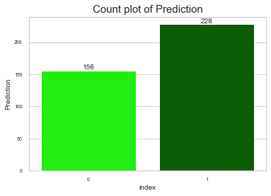

```python
barPlot(futureDf, "Prediction")
```

##### Probabilities of Prediction

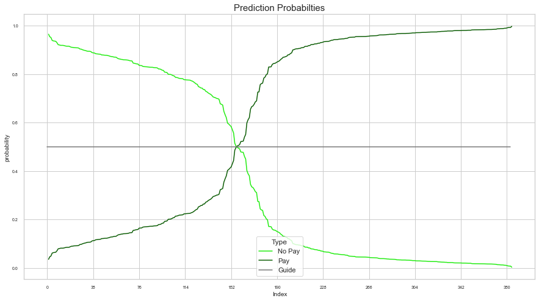

```python
indexList = list(range(len(futureProbDf))) + list(range(len(futureProbDf)))
futureProbDfLine = pd.melt(futureProbDf.reset_index(), ['index']).rename(columns={"variable" : "Type", "value" : "probability"})
futureProbDfLine['index'] = indexList
futureProbDfLine["index"] += 1
linePlot(futureProbDfLine, colName="probability", hue = "Type", xLabel= "Index", yLabel="probability", graphTitle="Prediction Probabilties", figSize=[15,8], splitLine=True)
```

##### Probabilities of Unsure Predictions

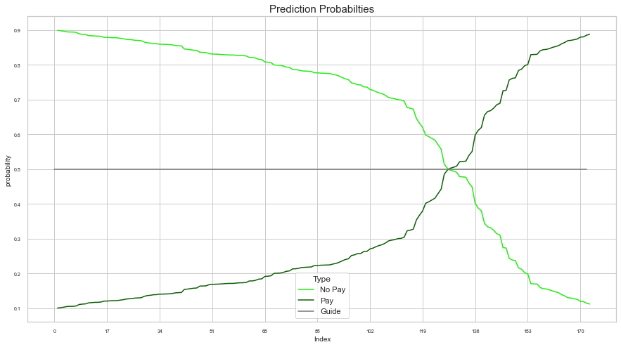

```python
futureProbDfFilter = futureProbDf[(futureProbDf["Pay"] > 0.1) & (futureProbDf["Pay"] < 0.9)]
indexList = list(range(len(futureProbDfFilter))) + list(range(len(futureProbDfFilter)))
futureProbDfLine = pd.melt(futureProbDfFilter.reset_index(), ['index']).rename(columns={"variable" : "Type", "value" : "probability"})
futureProbDfLine['index'] = indexList
futureProbDfLine["index"] += 1
linePlot(futureProbDfLine, colName="probability", hue = "Type", xLabel= "Index", yLabel="probability", graphTitle="Prediction Probabilties", figSize=[15,8], splitLine=True)
```

```python
futureProbDf['acctrefno'] = dfFuture['acctrefno']
futureProbDf = pd.merge(futureProbDf, dfFuture, on="acctrefno")
futureProbDfFilter = futureProbDf[(futureProbDf["No Pay"] > 0.1) & (futureProbDf["No Pay"] < 0.9)]
printTableHtml(futureProbDfFilter)
```

|  | No Pay | Pay | acctrefno | transaction_code | payment_number | state | city | trunc_zip | disable_NCOA | contact_method | loan_class1_no | loan_class2_no | days_in_current_period | current_payoff_balance | current_interest_rate | starting_interest_rate | interest_difference | vehicle_year | vehicle_make | vehicle_model | original_miles | original_value | payments_made | late_fee | late_fee_count | nsf_fees_count | online_payment_count | loan_balance_average | loan_balance_low | … |
| --- | --- | --- | --- | --- | --- | --- | --- | --- | --- | --- | --- | --- | --- | --- | --- | --- | --- | --- | --- | --- | --- | --- | --- | --- | --- | --- | --- | --- | --- | --- |
| 29 | 0.899189 | 0.100811 | 77083 | 204 | 2 | 19 | 135 | 45036 | 1 | 0 | 26 | 16 | 31 | 0.000000 | 16.750000 | 16.750000 | 0.000000 | 2018 | 14 | 23 | 28635 | 19958.000000 | 7 | 23.750000 | 3 | 2 | 0 | 17882.870000 | 0.000000 | … |
| 30 | 0.898007 | 0.101993 | 75552 | 204 | 2 | 19 | 95 | 43119 | 1 | 0 | 1 | 19 | 31 | 0.000000 | 16.750000 | 16.750000 | 0.000000 | 2015 | 24 | 126 | 80035 | 17150.000000 | 10 | 22.114285 | 7 | 1 | 17 | 19087.770000 | -425.250000 | … |
| 31 | 0.896664 | 0.103336 | 76564 | 204 | 6 | 3 | 12 | 80018 | 1 | 0 | 1 | 19 | 31 | 0.000000 | 16.750000 | 16.750000 | 0.000000 | 2014 | 17 | 22 | 74927 | 16539.000000 | 8 | 15.000000 | 5 | 3 | 0 | 13499.000000 | -478.380000 | … |
| 32 | 0.894805 | 0.105195 | 79539 | 204 | 1 | 3 | 136 | 80123 | 1 | 0 | 1 | 18 | 31 | 0.000000 | 14.750000 | 14.750000 | 0.000000 | 2014 | 8 | 33 | 49123 | 10210.000000 | 3 | 15.000000 | 1 | 0 | 0 | 6492.860000 | -351.990000 | … |
| 33 | 0.894385 | 0.105615 | 78231 | 206 | 3 | 19 | 259 | 45895 | 0 | 1 | 23 | 19 | 31 | 0.000000 | 16.750000 | 16.750000 | 0.000000 | 2021 | 11 | 80 | 22 | 37823.360000 | 4 | 42.015000 | 2 | 0 | 0 | 29126.610000 | -2050.960000 | … |
| 34 | 0.894323 | 0.105677 | 76093 | 204 | 8 | 6 | 110 | 52233 | 1 | 0 | 23 | 15 | 31 | 0.000000 | 16.750000 | 16.750000 | 0.000000 | 2014 | 18 | 111 | 100220 | 12900.000000 | 14 | 22.238181 | 11 | 0 | 24 | 15754.180000 | -406.350000 | … |
| 35 | 0.893188 | 0.106812 | 75594 | 204 | 2 | 19 | 6 | 45102 | 0 | 1 | 2 | 19 | 31 | 0.000000 | 14.750000 | 14.750000 | 0.000000 | 2017 | 14 | 10 | 75789 | 17775.000000 | 2 | 20.000000 | 1 | 0 | 0 | 6685.900000 | 0.000000 | … |
| 36 | 0.888982 | 0.111018 | 75727 | 206 | 3 | 11 | 140 | 40215 | 1 | 0 | 2 | 19 | 61 | 0.000000 | 14.750000 | 14.750000 | 0.000000 | 2017 | 14 | 23 | 34941 | 19800.000000 | 5 | 23.570000 | 1 | 0 | 11 | 20030.470000 | 0.000000 | … |
| 37 | 0.887842 | 0.112158 | 77001 | 204 | 7 | 19 | 275 | 43701 | 1 | 0 | 26 | 15 | 31 | 0.000000 | 15.750000 | 15.750000 | 0.000000 | 2016 | 17 | 22 | 56766 | 18525.000000 | 10 | 20.292000 | 5 | 0 | 11 | 17263.680000 | -238.260000 | … |
| 38 | 0.887248 | 0.112752 | 75888 | 206 | 12 | 3 | 141 | 80537 | 0 | 1 | 23 | 16 | 31 | 0.000000 | 18.750000 | 18.750000 | 0.000000 | 2016 | 29 | 88 | 76013 | 12762.000000 | 15 | 15.000000 | 4 | 0 | 3 | 15436.890000 | 0.000000 | … |
| 39 | 0.884249 | 0.115751 | 75732 | 206 | 2 | 15 | 101 | 27534 | 0 | 1 | 23 | 15 | 28 | 0.000000 | 14.750000 | 14.750000 | 0.000000 | 2019 | 11 | 47 | 28358 | 15045.000000 | 9 | 6.000000 | 1 | 0 | 0 | 11389.490000 | 0.000000 | … |
| 40 | 0.883671 | 0.116329 | 76021 | 204 | 5 | 24 | 258 | 23455 | 0 | 1 | 26 | 19 | 61 | 0.000431 | 14.750000 | 14.750000 | 0.000000 | 2014 | 24 | 72 | 93564 | 12975.000000 | 5 | 15.275000 | 2 | 0 | 0 | 3773.030000 | 0.000000 | … |
| 41 | 0.882837 | 0.117163 | 75830 | 206 | 1 | 18 | 133 | 89142 | 0 | 1 | 2 | 18 | 30 | 0.000000 | 14.750000 | 14.750000 | 0.000000 | 2013 | 2 | 1 | 58821 | 15458.000000 | 16 | 15.000000 | 1 | 1 | 1 | 18855.120000 | -352.640000 | … |
| 42 | 0.882768 | 0.117232 | 76473 | 206 | 7 | 19 | 237 | 43074 | 1 | 0 | 2 | 18 | 30 | 0.000000 | 14.750000 | 14.750000 | 0.000000 | 2019 | 24 | 101 | 3456 | 26200.000000 | 10 | 20.000000 | 0 | 0 | 6 | 13392.170000 | -626.550000 | … |
| 43 | 0.881930 | 0.118070 | 77101 | 204 | 5 | 8 | 162 | 61265 | 0 | 1 | 26 | 20 | 28 | 0.000000 | 16.750000 | 16.750000 | 0.000000 | 2021 | 24 | 102 | 13 | 27985.000000 | 5 | 32.520000 | 1 | 0 | 3 | 28181.300000 | 0.000000 | … |
| 44 | 0.879189 | 0.120811 | 75486 | 207 | 1 | 23 | 182 | 84401 | 1 | 0 | 1 | 20 | 31 | 0.000000 | 17.990000 | 17.990000 | 0.000000 | 2019 | 24 | 102 | 44800 | 18827.000000 | 6 | 30.000000 | 2 | 0 | 6 | 18456.050000 | -237.950000 | … |
| 45 | 0.879151 | 0.120849 | 76733 | 204 | 12 | 24 | 268 | 23185 | 1 | 0 | 23 | 16 | 31 | 0.000000 | 18.750000 | 18.750000 | 0.000000 | 2013 | 15 | 38 | 120093 | 6175.000000 | 12 | 12.470000 | 1 | 0 | 0 | 3734.450000 | 0.000000 | … |
| 46 | 0.878365 | 0.121635 | 80158 | 204 | 5 | 9 | 84 | 47710 | 0 | 1 | 23 | 16 | 61 | 0.000000 | 16.750000 | 16.750000 | 0.000000 | 2012 | 29 | 40 | 63076 | 10912.500000 | 5 | 15.000000 | 1 | 0 | 0 | 12609.520000 | 0.000000 | … |
| 47 | 0.877961 | 0.122039 | 75428 | 204 | 6 | 25 | 125 | 98301 | 1 | 0 | 23 | 16 | 30 | 0.000000 | 16.750000 | 16.750000 | 0.000000 | 2015 | 17 | 98 | 78528 | 16594.000000 | 17 | 20.120000 | 10 | 0 | 0 | 18419.790000 | 0.000000 | … |
| 48 | 0.877936 | 0.122064 | 75466 | 204 | 12 | 0 | 206 | 35133 | 1 | 0 | 23 | 15 | 61 | 0.000000 | 16.750000 | 16.750000 | 0.000000 | 2018 | 15 | 38 | 46483 | 17575.000000 | 12 | 18.890000 | 1 | 0 | 0 | 15432.950000 | -460.620000 | … |
| 49 | 0.876698 | 0.123302 | 76734 | 206 | 4 | 18 | 133 | 89108 | 0 | 1 | 23 | 16 | 31 | 0.000000 | 16.750000 | 16.750000 | 0.000000 | 2017 | 11 | 52 | 78705 | 14453.000000 | 13 | 15.000000 | 1 | 0 | 28 | 14524.780000 | 0.000000 | … |
| 50 | 0.875527 | 0.124473 | 75731 | 204 | 14 | 5 | 122 | 30143 | 0 | 1 | 1 | 19 | 30 | 0.000000 | 16.750000 | 16.750000 | 0.000000 | 2021 | 17 | 98 | 74 | 26074.000000 | 16 | 31.260000 | 1 | 0 | 28 | 25599.730000 | -1264.910000 | … |
| 51 | 0.873638 | 0.126362 | 76257 | 204 | 8 | 14 | 221 | 63123 | 1 | 0 | 26 | 20 | 31 | 0.000000 | 17.990000 | 17.990000 | 0.000000 | 2019 | 17 | 22 | 33440 | 25893.000000 | 13 | 24.761428 | 7 | 1 | 29 | 25069.530000 | -498.520000 | … |
| 52 | 0.872609 | 0.127391 | 78788 | 207 | 2 | 19 | 43 | 45229 | 1 | 0 | 27 | 18 | 30 | 0.000000 | 14.750000 | 14.750000 | 0.000000 | 2018 | 8 | 66 | 33959 | 23091.000000 | 4 | 28.870000 | 2 | 0 | 0 | 21798.550000 | -1499.900000 | … |
| 53 | 0.872156 | 0.127844 | 75733 | 206 | 4 | 11 | 99 | 42141 | 0 | 1 | 1 | 16 | 31 | 0.000000 | 14.750000 | 14.750000 | 0.000000 | 2019 | 24 | 106 | 32996 | 18150.000000 | 13 | 23.227500 | 12 | 2 | 21 | 21542.030000 | 0.000000 | … |
| 54 | 0.870496 | 0.129504 | 75443 | 206 | 4 | 1 | 189 | 86434 | 0 | 1 | 23 | 16 | 31 | 0.000000 | 16.750000 | 16.750000 | 0.000000 | 2017 | 15 | 38 | 21697 | 16899.000000 | 9 | 19.793333 | 3 | 0 | 13 | 17106.950000 | 0.000000 | … |
| 55 | 0.870223 | 0.129777 | 76070 | 206 | 3 | 19 | 54 | 43227 | 1 | 0 | 1 | 20 | 28 | 0.000000 | 17.750000 | 17.750000 | 0.000000 | 2019 | 5 | 41 | 21899 | 22975.000000 | 7 | 31.470000 | 1 | 1 | 4 | 25988.610000 | -334.220000 | … |
| 56 | 0.869506 | 0.130494 | 75976 | 204 | 1 | 1 | 251 | 85704 | 1 | 0 | 1 | 19 | 31 | 0.000000 | 14.750000 | 14.750000 | 0.000000 | 2022 | 15 | 67 | 22 | 26147.000000 | 8 | 27.863333 | 3 | 1 | 12 | 26276.770000 | 0.000000 | … |
| 57 | 0.865619 | 0.134381 | 75613 | 204 | 17 | 0 | 213 | 36567 | 1 | 0 | 1 | 20 | 30 | 0.000000 | 18.750000 | 18.750000 | 0.000000 | 2020 | 29 | 88 | 10830 | 20850.000000 | 17 | 23.125000 | 10 | 0 | 3 | 19157.820000 | -789.830000 | … |
| 58 | 0.863300 | 0.136700 | 77332 | 206 | 5 | 8 | 176 | 61761 | 1 | 0 | 1 | 20 | 31 | 0.000000 | 16.750000 | 16.750000 | 0.000000 | 2018 | 5 | 41 | 27682 | 26290.000000 | 10 | 28.730000 | 4 | 0 | 6 | 23887.310000 | 0.000000 | … |

[output cut: 143 more lines]

```python
md(f"Before filtering the length of the dataframe was ***{futureDf.shape[0]}*** after deletion the width of the dataframe is ***{futureProbDfFilter.shape[0]}*** a difference of ***{futureDf.shape[0] - futureProbDfFilter.shape[0]}*** meaning that the entries where the model is unsure account for only ***{round(futureProbDfFilter.shape[0]/futureDf.shape[0] * 100,2)}%*** of the entries")
```

Before filtering the length of the dataframe was *384* after deletion the width of the dataframe is *173* a difference of *211* meaning that the entries where the model is unsure account for only *45.05%* of the entries

## Evaluation of One Account

### Create Data Frames

```python
dummyDf['paid'] = dfTarget
# TODO Upload Target and Dummy to Database, Write Cleaning Script
customerData = pd.DataFrame(dummyDf.loc[dummyDf['acctrefno'] == 75210])
customerData.sort_values("payment_number", ascending=True, inplace=True)
customerData.reset_index(drop=True, inplace=True)
```

### Prep for Machine Learning

```python
# Dummy encode
customerTarget = customerData['paid']
#customerData.drop("paid", axis = 1, inplace = True)
dummyCustomer = pd.get_dummies(customerData)

# Scale
column_names = list(dummyCustomer.keys())

dataframe_scaler = joblib.load('scaler.gz')

CustomerScaled = dataframe_scaler.transform(dummyCustomer)
CustomerScaled = pd.DataFrame(data=CustomerScaled, columns=column_names)

CustomerScaled.drop("paid", axis = 1, inplace = True)
print("The dataframe completed scaling.")
```

```
The dataframe completed scaling.
```

### Create Future Data

```python
customerFuture = pd.DataFrame(CustomerScaled.loc[CustomerScaled['payment_number'] == max(CustomerScaled['payment_number'])])
customerFuture['payment_number'] = customerFuture['payment_number'] + 1
```

### Load Model

```python
xgb_model_loaded = pickle.load(open(file_name, "rb"))
```

### Run Model

```python
CustomerPredProb = xgb_model_loaded.predict_proba(CustomerScaled)
CustomerProbDf = pd.DataFrame(CustomerPredProb).rename(columns={0 : "No Pay", 1 : "Pay"})
CustomerProbDf = CustomerProbDf.sort_values("No Pay", ascending=False)
```

```python
CustomerDf = dummyCustomer
CustomerDf['actual'] = customerTarget
CustomerDf['payProb'] = round(CustomerProbDf['Pay']*100,2)
CustomerDf
```

|  | transaction_code | payment_number | acctrefno | state | city | trunc_zip | disable_NCOA | contact_method | loan_class1_no | loan_class2_no | days_in_current_period | current_payoff_balance | current_interest_rate | starting_interest_rate | interest_difference | vehicle_year | vehicle_make | vehicle_model | original_miles | original_value | payments_made | late_fee | late_fee_count | nsf_fees_count | online_payment_count | loan_balance_average | loan_balance_low | days_late_30 | days_late_60 | … |
| --- | --- | --- | --- | --- | --- | --- | --- | --- | --- | --- | --- | --- | --- | --- | --- | --- | --- | --- | --- | --- | --- | --- | --- | --- | --- | --- | --- | --- | --- | --- |
| 0 | 204 | 1 | 75210 | 1 | 251 | 85706 | 0 | 1 | 23 | 15 | 28 | 0.0 | 16.75 | 16.75 | 0.0 | 2015 | 7 | 0 | 92498 | 10799.0 | 11 | 0.0 | 0 | 0 | 20 | 14090.65 | 0.0 | 0 | 0 | … |
| 1 | 206 | 1 | 75210 | 1 | 251 | 85706 | 0 | 1 | 23 | 15 | 28 | 0.0 | 16.75 | 16.75 | 0.0 | 2015 | 7 | 0 | 92498 | 10799.0 | 11 | 0.0 | 0 | 0 | 20 | 14090.65 | 0.0 | 0 | 0 | … |
| 2 | 204 | 2 | 75210 | 1 | 251 | 85706 | 0 | 1 | 23 | 15 | 28 | 0.0 | 16.75 | 16.75 | 0.0 | 2015 | 7 | 0 | 92498 | 10799.0 | 11 | 0.0 | 0 | 0 | 20 | 14090.65 | 0.0 | 0 | 0 | … |
| 3 | 206 | 2 | 75210 | 1 | 251 | 85706 | 0 | 1 | 23 | 15 | 28 | 0.0 | 16.75 | 16.75 | 0.0 | 2015 | 7 | 0 | 92498 | 10799.0 | 11 | 0.0 | 0 | 0 | 20 | 14090.65 | 0.0 | 0 | 0 | … |
| 4 | 204 | 3 | 75210 | 1 | 251 | 85706 | 0 | 1 | 23 | 15 | 28 | 0.0 | 16.75 | 16.75 | 0.0 | 2015 | 7 | 0 | 92498 | 10799.0 | 11 | 0.0 | 0 | 0 | 20 | 14090.65 | 0.0 | 0 | 0 | … |
| 5 | 206 | 3 | 75210 | 1 | 251 | 85706 | 0 | 1 | 23 | 15 | 28 | 0.0 | 16.75 | 16.75 | 0.0 | 2015 | 7 | 0 | 92498 | 10799.0 | 11 | 0.0 | 0 | 0 | 20 | 14090.65 | 0.0 | 0 | 0 | … |
| 6 | 204 | 4 | 75210 | 1 | 251 | 85706 | 0 | 1 | 23 | 15 | 28 | 0.0 | 16.75 | 16.75 | 0.0 | 2015 | 7 | 0 | 92498 | 10799.0 | 11 | 0.0 | 0 | 0 | 20 | 14090.65 | 0.0 | 0 | 0 | … |
| 7 | 206 | 4 | 75210 | 1 | 251 | 85706 | 0 | 1 | 23 | 15 | 28 | 0.0 | 16.75 | 16.75 | 0.0 | 2015 | 7 | 0 | 92498 | 10799.0 | 11 | 0.0 | 0 | 0 | 20 | 14090.65 | 0.0 | 0 | 0 | … |
| 8 | 204 | 5 | 75210 | 1 | 251 | 85706 | 0 | 1 | 23 | 15 | 28 | 0.0 | 16.75 | 16.75 | 0.0 | 2015 | 7 | 0 | 92498 | 10799.0 | 11 | 0.0 | 0 | 0 | 20 | 14090.65 | 0.0 | 0 | 0 | … |
| 9 | 206 | 5 | 75210 | 1 | 251 | 85706 | 0 | 1 | 23 | 15 | 28 | 0.0 | 16.75 | 16.75 | 0.0 | 2015 | 7 | 0 | 92498 | 10799.0 | 11 | 0.0 | 0 | 0 | 20 | 14090.65 | 0.0 | 0 | 0 | … |
| 10 | 204 | 6 | 75210 | 1 | 251 | 85706 | 0 | 1 | 23 | 15 | 28 | 0.0 | 16.75 | 16.75 | 0.0 | 2015 | 7 | 0 | 92498 | 10799.0 | 11 | 0.0 | 0 | 0 | 20 | 14090.65 | 0.0 | 0 | 0 | … |
| 11 | 206 | 6 | 75210 | 1 | 251 | 85706 | 0 | 1 | 23 | 15 | 28 | 0.0 | 16.75 | 16.75 | 0.0 | 2015 | 7 | 0 | 92498 | 10799.0 | 11 | 0.0 | 0 | 0 | 20 | 14090.65 | 0.0 | 0 | 0 | … |
| 12 | 204 | 7 | 75210 | 1 | 251 | 85706 | 0 | 1 | 23 | 15 | 28 | 0.0 | 16.75 | 16.75 | 0.0 | 2015 | 7 | 0 | 92498 | 10799.0 | 11 | 0.0 | 0 | 0 | 20 | 14090.65 | 0.0 | 0 | 0 | … |
| 13 | 206 | 7 | 75210 | 1 | 251 | 85706 | 0 | 1 | 23 | 15 | 28 | 0.0 | 16.75 | 16.75 | 0.0 | 2015 | 7 | 0 | 92498 | 10799.0 | 11 | 0.0 | 0 | 0 | 20 | 14090.65 | 0.0 | 0 | 0 | … |
| 14 | 204 | 8 | 75210 | 1 | 251 | 85706 | 0 | 1 | 23 | 15 | 28 | 0.0 | 16.75 | 16.75 | 0.0 | 2015 | 7 | 0 | 92498 | 10799.0 | 11 | 0.0 | 0 | 0 | 20 | 14090.65 | 0.0 | 0 | 0 | … |
| 15 | 206 | 8 | 75210 | 1 | 251 | 85706 | 0 | 1 | 23 | 15 | 28 | 0.0 | 16.75 | 16.75 | 0.0 | 2015 | 7 | 0 | 92498 | 10799.0 | 11 | 0.0 | 0 | 0 | 20 | 14090.65 | 0.0 | 0 | 0 | … |
| 16 | 206 | 9 | 75210 | 1 | 251 | 85706 | 0 | 1 | 23 | 15 | 28 | 0.0 | 16.75 | 16.75 | 0.0 | 2015 | 7 | 0 | 92498 | 10799.0 | 11 | 0.0 | 0 | 0 | 20 | 14090.65 | 0.0 | 0 | 0 | … |
| 17 | 204 | 9 | 75210 | 1 | 251 | 85706 | 0 | 1 | 23 | 15 | 28 | 0.0 | 16.75 | 16.75 | 0.0 | 2015 | 7 | 0 | 92498 | 10799.0 | 11 | 0.0 | 0 | 0 | 20 | 14090.65 | 0.0 | 0 | 0 | … |
| 18 | 206 | 10 | 75210 | 1 | 251 | 85706 | 0 | 1 | 23 | 15 | 28 | 0.0 | 16.75 | 16.75 | 0.0 | 2015 | 7 | 0 | 92498 | 10799.0 | 11 | 0.0 | 0 | 0 | 20 | 14090.65 | 0.0 | 0 | 0 | … |
| 19 | 204 | 10 | 75210 | 1 | 251 | 85706 | 0 | 1 | 23 | 15 | 28 | 0.0 | 16.75 | 16.75 | 0.0 | 2015 | 7 | 0 | 92498 | 10799.0 | 11 | 0.0 | 0 | 0 | 20 | 14090.65 | 0.0 | 0 | 0 | … |
| 20 | 204 | 11 | 75210 | 1 | 251 | 85706 | 0 | 1 | 23 | 15 | 28 | 0.0 | 16.75 | 16.75 | 0.0 | 2015 | 7 | 0 | 92498 | 10799.0 | 11 | 0.0 | 0 | 0 | 20 | 14090.65 | 0.0 | 0 | 0 | … |
| 21 | 206 | 11 | 75210 | 1 | 251 | 85706 | 0 | 1 | 23 | 15 | 28 | 0.0 | 16.75 | 16.75 | 0.0 | 2015 | 7 | 0 | 92498 | 10799.0 | 11 | 0.0 | 0 | 0 | 20 | 14090.65 | 0.0 | 0 | 0 | … |

```python
stop = timeit.default_timer()

print(f'Total Runtime: {str(datetime.timedelta(seconds = int(stop - start)))}')

# Stats
# Source Code Lines = 3225
```

```
Total Runtime: 0:04:32
```

```python
dummyDf
```

|  | transaction_code | payment_number | acctrefno | state | city | trunc_zip | disable_NCOA | contact_method | loan_class1_no | loan_class2_no | days_in_current_period | current_payoff_balance | current_interest_rate | starting_interest_rate | interest_difference | vehicle_year | vehicle_make | vehicle_model | original_miles | original_value | payments_made | late_fee | late_fee_count | nsf_fees_count | online_payment_count | loan_balance_average | loan_balance_low | days_late_30 | days_late_60 | … |
| --- | --- | --- | --- | --- | --- | --- | --- | --- | --- | --- | --- | --- | --- | --- | --- | --- | --- | --- | --- | --- | --- | --- | --- | --- | --- | --- | --- | --- | --- | --- |
| 0 | 204 | 1 | 75210 | 1 | 251 | 85706 | 0 | 1 | 23 | 15 | 28 | 0.0 | 16.75 | 16.75 | 0.0 | 2015 | 7 | 0 | 92498 | 10799.0 | 11 | 0.0 | 0 | 0 | 20 | 14090.65 | 0.00 | 0 | 0 | … |
| 1 | 204 | 2 | 75210 | 1 | 251 | 85706 | 0 | 1 | 23 | 15 | 28 | 0.0 | 16.75 | 16.75 | 0.0 | 2015 | 7 | 0 | 92498 | 10799.0 | 11 | 0.0 | 0 | 0 | 20 | 14090.65 | 0.00 | 0 | 0 | … |
| 2 | 204 | 3 | 75210 | 1 | 251 | 85706 | 0 | 1 | 23 | 15 | 28 | 0.0 | 16.75 | 16.75 | 0.0 | 2015 | 7 | 0 | 92498 | 10799.0 | 11 | 0.0 | 0 | 0 | 20 | 14090.65 | 0.00 | 0 | 0 | … |
| 3 | 204 | 4 | 75210 | 1 | 251 | 85706 | 0 | 1 | 23 | 15 | 28 | 0.0 | 16.75 | 16.75 | 0.0 | 2015 | 7 | 0 | 92498 | 10799.0 | 11 | 0.0 | 0 | 0 | 20 | 14090.65 | 0.00 | 0 | 0 | … |
| 4 | 204 | 5 | 75210 | 1 | 251 | 85706 | 0 | 1 | 23 | 15 | 28 | 0.0 | 16.75 | 16.75 | 0.0 | 2015 | 7 | 0 | 92498 | 10799.0 | 11 | 0.0 | 0 | 0 | 20 | 14090.65 | 0.00 | 0 | 0 | … |
| ... | ... | ... | ... | ... | ... | ... | ... | ... | ... | ... | ... | ... | ... | ... | ... | ... | ... | ... | ... | ... | ... | ... | ... | ... | ... | ... | ... | ... | ... | … |
| 8452 | 204 | 1 | 82524 | 8 | 42 | 60643 | 0 | 1 | 23 | 24 | 31 | 0.0 | 20.75 | 20.75 | 0.0 | 2019 | 5 | 70 | 47449 | 21572.0 | 1 | 0.0 | 0 | 0 | 0 | 11953.63 | -716.82 | 0 | 0 | … |
| 8453 | 205 | 1 | 82524 | 8 | 42 | 60643 | 0 | 1 | 23 | 24 | 31 | 0.0 | 20.75 | 20.75 | 0.0 | 2019 | 5 | 70 | 47449 | 21572.0 | 1 | 0.0 | 0 | 0 | 0 | 11953.63 | -716.82 | 0 | 0 | … |
| 8454 | 206 | 1 | 82524 | 8 | 42 | 60643 | 0 | 1 | 23 | 24 | 31 | 0.0 | 20.75 | 20.75 | 0.0 | 2019 | 5 | 70 | 47449 | 21572.0 | 1 | 0.0 | 0 | 0 | 0 | 11953.63 | -716.82 | 0 | 0 | … |
| 8455 | 206 | 1 | 82524 | 8 | 42 | 60643 | 0 | 1 | 23 | 24 | 31 | 0.0 | 20.75 | 20.75 | 0.0 | 2019 | 5 | 70 | 47449 | 21572.0 | 1 | 0.0 | 0 | 0 | 0 | 11953.63 | -716.82 | 0 | 0 | … |
| 8456 | 207 | 1 | 82524 | 8 | 42 | 60643 | 0 | 1 | 23 | 24 | 31 | 0.0 | 20.75 | 20.75 | 0.0 | 2019 | 5 | 70 | 47449 | 21572.0 | 1 | 0.0 | 0 | 0 | 0 | 11953.63 | -716.82 | 0 | 0 | … |

8457 rows × 91 columns